# Home Credit Default Risk

EDA

Roman Brock, Che Diaz Fadel, Kalyani Joshi, and Chris Porter

# 1 Load Libraries

```r
library(tidyverse)
library(skimr)
library(scales)
library(ggplot2)
library(corrplot)
library(stringr)
library(reshape2)
library(gridExtra)
library(grid)
library(gmodels)
```

# 2 Reading train file

```r
#Read application_train.csv file
app_train <- read.csv("../data/application_train.csv")
```

# 3 Viewing data

```r
#View structure and summary of data
str(app_train)
```

```
## 'data.frame':    307511 obs. of  122 variables:
##  $ SK_ID_CURR                  : int  100002 100003 100004 100006 100007 100008 100009 100010 100011 100012 ...
##  $ TARGET                      : int  1 0 0 0 0 0 0 0 0 0 ...
##  $ NAME_CONTRACT_TYPE          : chr  "Cash loans" "Cash loans" "Revolving loans" "Cash loans" ...
##  $ CODE_GENDER                 : chr  "M" "F" "M" "F" ...
##  $ FLAG_OWN_CAR                : chr  "N" "N" "Y" "N" ...
##  $ FLAG_OWN_REALTY             : chr  "Y" "N" "Y" "Y" ...
##  $ CNT_CHILDREN                : int  0 0 0 0 0 0 1 0 0 0 ...
##  $ AMT_INCOME_TOTAL            : num  202500 270000 67500 135000 121500 ...
##  $ AMT_CREDIT                  : num  406598 1293503 135000 312683 513000 ...
##  $ AMT_ANNUITY                 : num  24701 35699 6750 29687 21866 ...
##  $ AMT_GOODS_PRICE             : num  351000 1129500 135000 297000 513000 ...
##  $ NAME_TYPE_SUITE             : chr  "Unaccompanied" "Family" "Unaccompanied" "Unaccompanied" ...
##  $ NAME_INCOME_TYPE            : chr  "Working" "State servant" "Working" "Working" ...
##  $ NAME_EDUCATION_TYPE         : chr  "Secondary / secondary special" "Higher education" "Secondary / secondary special" "Secondary / secondary special" ...
```

[output cut: 86 more lines]

```r
summary(app_train$TARGET)
```

```
##    Min. 1st Qu.  Median    Mean 3rd Qu.    Max.
## 0.00000 0.00000 0.00000 0.08073 0.00000 1.00000
```

There are 307511 rows and 122 features including TARGET variable.The target is categorical variable classified as “0” for the loan was repaid on time with no difficulties and “1” indicating the client had payment difficulties.

# 4 Missing Value check

```r
#Checking missing value in target variable
missing_count <- sum(is.na(app_train$TARGET))
missing_count
```

```
## [1] 0
```

There are no missing values in Target variable

# 5 Check count distribution of target variable

```r
# View count of clients in each class
table(app_train$TARGET)
```

```
##
##      0      1
## 282686  24825
```

Here 24825 clients are observed to have payment difficulties, whereas 282686 people have no payment difficulties.

# 6 Visualize count distribution of target variable

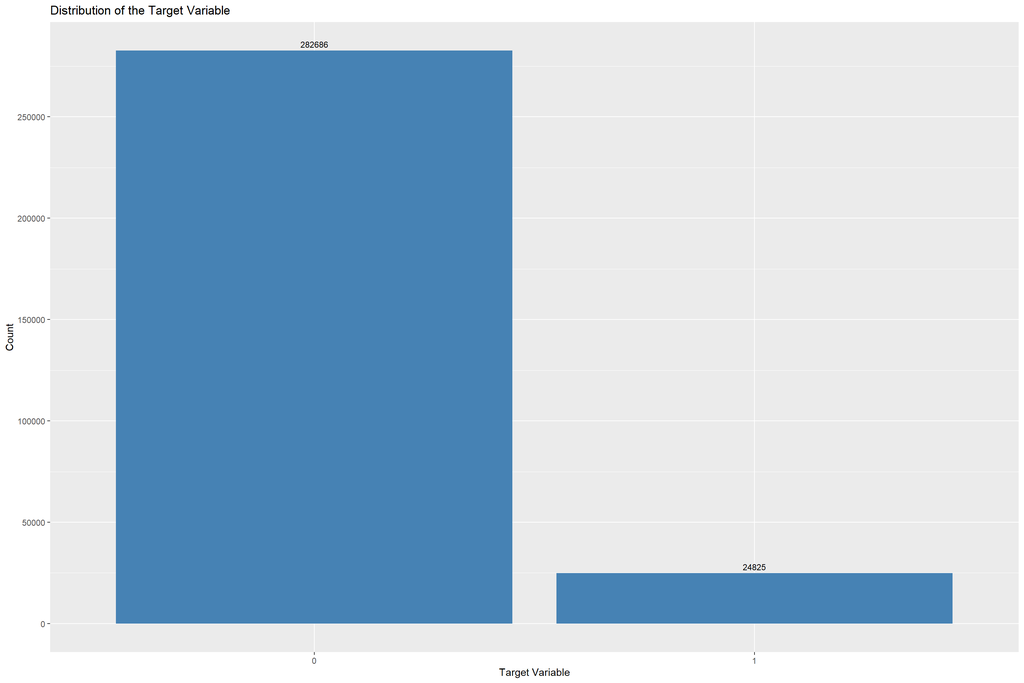

```r
library(ggplot2)
ggplot(app_train, aes(x = as.factor(TARGET))) +
  geom_bar(fill = "steelblue") +
  geom_text(stat = "count", aes(label = ..count..), vjust = -0.5, color = "black", size = 3) +
  labs(x = "Target Variable", y = "Count") +
  ggtitle("Distribution of the Target Variable") +
  scale_y_continuous(breaks = seq(0, max(table(app_train$TARGET)), by = 50000))
```

Above Target variable distribution shows that majority clients come under no payment difficulties class(0), only 24825 clients have payment difficulties.

```r
# View the proportion of target variable
proportion <- prop.table(table(app_train$TARGET)) * 100
proportion
```

```
##
##         0         1
## 91.927118  8.072882
```

91.92% of the clients are observed to have no payment difficulties, 8.07% clients face payment difficulties.The data looks unbalaced with respect target variable as proportion for class 0 is much higher (91.92%) than that of class 1 (8.07%)

# 7 Visualize the proportion of target variable

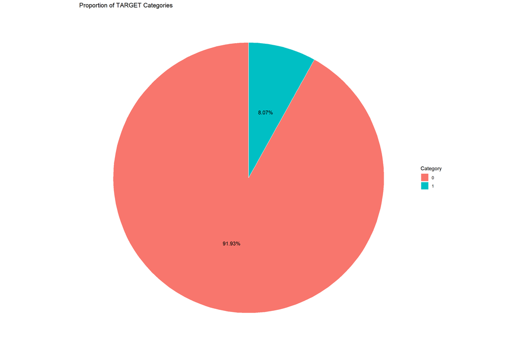

```r
# Calculate the proportion and convert it to percentages
proportion <- prop.table(table(app_train$TARGET)) * 100

# Create a data frame for plotting
pie_data <- data.frame(category = names(proportion), proportion = proportion)

# Create the pie chart using ggplot
pie_chart <- ggplot(pie_data, aes(x = "", y = proportion, fill = category)) +
  geom_bar(stat = "identity", width = 1, color = "white") +
  coord_polar("y", start = 0) +
  theme_void() +
  labs(fill = "Category") +
  geom_text(aes(label = paste0(round(proportion, 2), "%")), position = position_stack(vjust = 0.5)) +
  labs(title = "Proportion of TARGET Categories")

# Display the pie chart
print(pie_chart)
```

# 8 Determine accuracy for majority class classifier

```r
# Count of majority class
majority_count <- max(table(app_train$TARGET))

# Total number of clients in the target class
total_count <- length(app_train$TARGET)

# Accuracy for majority class
accuracy <- majority_count / total_count

accuracy
```

```
## [1] 0.9192712
```

The accuracy for majority class classifier “0” (client with no payment difficulties) is 91.92% which is same as the proportion of class “0” clients in the data.

# 9 Correlation of Target and Numeric Predictors

```r
#Getting list of Top5 positive and top 5 negative predictors

# Separate numeric predictors
numeric_vars <- app_train %>%
                select_if(is.numeric)

# Calculate correlation between numeric predictors and target variable
cor_target <- cor(numeric_vars, numeric_vars$TARGET, use = "pairwise.complete.obs", method = "pearson")
cor_target
```

```
##                                       [,1]
## SK_ID_CURR                   -0.0021084690
## TARGET                        1.0000000000
## CNT_CHILDREN                  0.0191871336
## AMT_INCOME_TOTAL             -0.0039818656
## AMT_CREDIT                   -0.0303692865
## AMT_ANNUITY                  -0.0128165615
## AMT_GOODS_PRICE              -0.0396452812
## REGION_POPULATION_RELATIVE   -0.0372271485
## DAYS_BIRTH                    0.0782393083
## DAYS_EMPLOYED                -0.0449316627
## DAYS_REGISTRATION             0.0419748628
## DAYS_ID_PUBLISH               0.0514571726
## OWN_CAR_AGE                   0.0376115643
## FLAG_MOBIL                    0.0005343956
## FLAG_EMP_PHONE                0.0459822197
## FLAG_WORK_PHONE               0.0285243224
## FLAG_CONT_MOBILE              0.0003701268
## FLAG_PHONE                   -0.0238062723
## FLAG_EMAIL                   -0.0017583834
## CNT_FAM_MEMBERS               0.0093077844
## REGION_RATING_CLIENT          0.0588990149
## REGION_RATING_CLIENT_W_CITY   0.0608926676
## HOUR_APPR_PROCESS_START      -0.0241658314
## REG_REGION_NOT_LIVE_REGION    0.0055759445
## REG_REGION_NOT_WORK_REGION    0.0069419075
## LIVE_REGION_NOT_WORK_REGION   0.0028194792
## REG_CITY_NOT_LIVE_CITY        0.0443953748
## REG_CITY_NOT_WORK_CITY        0.0509944644
## LIVE_CITY_NOT_WORK_CITY       0.0325183411
## EXT_SOURCE_1                 -0.1553171261
## EXT_SOURCE_2                 -0.1604716716
## EXT_SOURCE_3                 -0.1789186976
## APARTMENTS_AVG               -0.0294975646
## BASEMENTAREA_AVG             -0.0227457432
## YEARS_BEGINEXPLUATATION_AVG  -0.0097276733
## YEARS_BUILD_AVG              -0.0221492841
## COMMONAREA_AVG               -0.0185496616
## ELEVATORS_AVG                -0.0341987937
## ENTRANCES_AVG                -0.0191721820
```

[output cut: 52 more lines]

```
## FLAG_DOCUMENT_13             -0.0115832223
## FLAG_DOCUMENT_14             -0.0094638219
## FLAG_DOCUMENT_15             -0.0065356576
## FLAG_DOCUMENT_16             -0.0116146716
## FLAG_DOCUMENT_17             -0.0033775691
## FLAG_DOCUMENT_18             -0.0079523851
## FLAG_DOCUMENT_19             -0.0013575183
## FLAG_DOCUMENT_20              0.0002153936
## FLAG_DOCUMENT_21              0.0037086250
## AMT_REQ_CREDIT_BUREAU_HOUR    0.0009304246
## AMT_REQ_CREDIT_BUREAU_DAY     0.0027044014
## AMT_REQ_CREDIT_BUREAU_WEEK    0.0007877117
## AMT_REQ_CREDIT_BUREAU_MON    -0.0124624192
## AMT_REQ_CREDIT_BUREAU_QRT    -0.0020219274
## AMT_REQ_CREDIT_BUREAU_YEAR    0.0199298586
```

```r
# Create a data frame with predictor names and correlations
df <- data.frame(Target = "TARGET", Variable = colnames(numeric_vars), Correlation = cor_target)

# Sort the data frame by correlation in descending order
sorted_df <- df[order(-abs(df$Correlation)), , drop = FALSE]

# Extract the top 10 positive and top 10 negative correlations
top_pos <- head(sorted_df[sorted_df$Correlation > 0, ], 10)
top_neg <- head(sorted_df[sorted_df$Correlation < 0, ], 10)
```

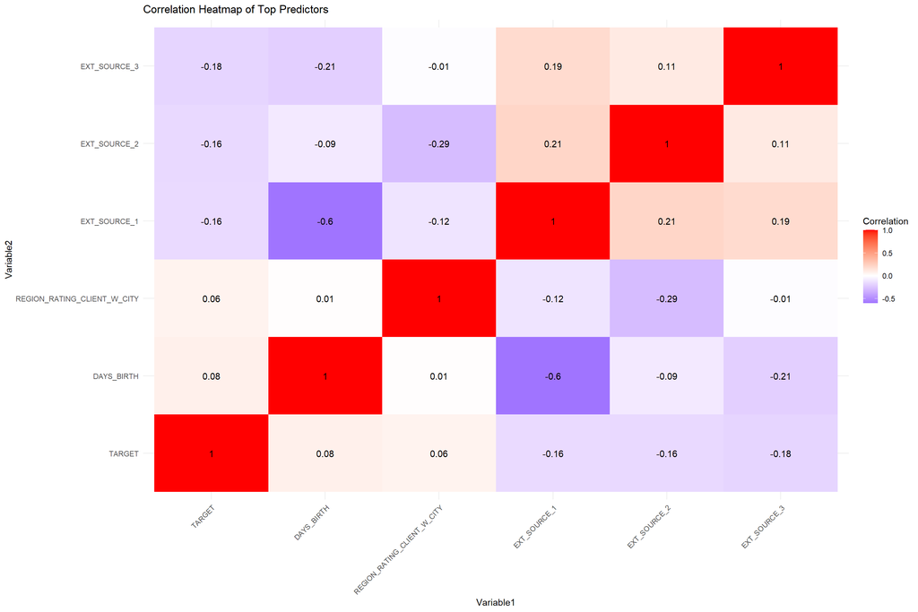

```r
##Visualizing correlation using heatmap for numerical predictors with target

# Convert the correlation matrix to a data frame
cor_matrix <- cor(numeric_vars, use = "pairwise.complete.obs")
cor_df <- melt(cor_matrix)

# Rename the columns
colnames(cor_df) <- c("Variable1", "Variable2", "Correlation")

# Sort the correlations by the absolute value
cor_df <- cor_df[order(-abs(cor_df$Correlation)), ]

# Filter the correlations involving the target variable
cor_target <- subset(cor_df, Variable1 == "TARGET" | Variable2 == "TARGET")

# Select the top positive and negative correlations
top_pos <- head(subset(cor_target, Correlation > 0), 5)
top_neg <- head(subset(cor_target, Correlation < 0), 5)

# Combine the top positive and negative correlations
top_cor <- rbind(top_pos, top_neg)

# Filter the correlations involving the top positive and negative predictors
top_predictors <- c(top_pos$Variable1, top_pos$Variable2, top_neg$Variable1, top_neg$Variable2)
cor_top_predictors <- subset(cor_df, Variable1 %in% top_predictors & Variable2 %in% top_predictors)

# Visualize the correlations using a heatmap
ggplot(cor_top_predictors, aes(x = Variable1, y = Variable2, fill = Correlation)) +
  geom_tile() +
  scale_fill_gradient2(low = "blue", mid = "white", high = "red", midpoint = 0) +
  geom_text(aes(label = round(Correlation, 2)), color = "black") +
  theme_minimal() +
  theme(axis.text.x = element_text(angle = 45, hjust = 1)) +
  labs(title = "Correlation Heatmap of Top Predictors")
```

DAYS_BIRTH, REGION_RATING_CLIENT_W_CITY, REGION_RATING_CLIENT are the top 3 numerical predictors with positive correlation wrt TARGET, whereas EXT_SOURCE_3, EXT_SOURCE_2, EXT_SOURCE_1 are top 3 numerical predictors with negative correlation wrt TARGET.

# 10 Correlation of Target and Categorical Predictors

```r
# Select character variables
character_vars <- app_train %>%
                  select_if(is.character)

# Create a data frame to store correlation values
cor_df <- data.frame(variable = character(), correlation = numeric(), stringsAsFactors = FALSE)

# Calculate correlation with the target variable
for (var_name in colnames(character_vars)) {
  var <- character_vars[[var_name]]
  correlation <- cor(as.numeric(as.factor(var)), app_train$TARGET, use = "pairwise.complete.obs")
  cor_df <- cor_df %>% add_row(variable = var_name, correlation = correlation)
}
```

```r
## Listing top categorical predictors

# Sort the data frame by correlation in descending order
sorted_df <- cor_df %>% arrange(desc(correlation))

# Select the top 5 categorical predictors
top_categorical_predictors <- head(sorted_df, 10)

# Print the top 5 categorical predictors
print(top_categorical_predictors)
```

```
##                      variable  correlation
## 1         NAME_EDUCATION_TYPE  0.054698602
## 2                 CODE_GENDER  0.054692262
## 3            NAME_INCOME_TYPE  0.046829434
## 4             OCCUPATION_TYPE  0.041419035
## 5           NAME_HOUSING_TYPE  0.034488603
## 6             NAME_TYPE_SUITE  0.009692820
## 7  WEEKDAY_APPR_PROCESS_START  0.004001745
## 8          NAME_FAMILY_STATUS -0.004127226
## 9             FLAG_OWN_REALTY -0.006148388
## 10               FLAG_OWN_CAR -0.021850938
```

```r
# Reorder the levels of the categorical predictor variable
top_categorical_predictors$variable <- factor(top_categorical_predictors$variable,
                                             levels = top_categorical_predictors$variable[order(top_categorical_predictors$correlation)])
```

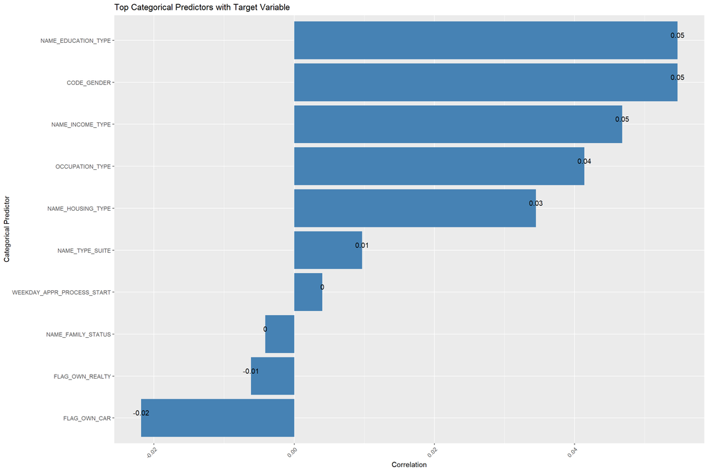

```r
##Visualizing categorical predictors with Target

# Create a bar plot of the top categorical predictors
ggplot(top_categorical_predictors, aes(x = variable, y = correlation, label = round(correlation, 2))) +
  geom_bar(stat = "identity", fill = "steelblue") +
  geom_text(vjust = -0.5) +
  labs(x = "Categorical Predictor", y = "Correlation") +
  ggtitle("Top Categorical Predictors with Target Variable") +
  theme(axis.text.x = element_text(angle = 45, hjust = 1)) +
  coord_flip() +
  scale_fill_manual(values = c("steelblue" = "steelblue"), guide = "none")
```

NAME_EDUCATION_TYPE, CODE_GENDER, NAME_INCOME_TYPE are the top 3 categorical predictors which has positive correlation wrt TARGET.

Join application_{train|test}.csv with transactional data in, for example, bureau.csv or previous_application.csv. This will require aggregating the transactional data to have the same grain as the application data.

```r
data <- read.csv('../data/application_train.csv')
data2 <- read.csv('../data/bureau.csv')
```

```r
head(data)
```

```
##   SK_ID_CURR TARGET NAME_CONTRACT_TYPE CODE_GENDER FLAG_OWN_CAR FLAG_OWN_REALTY CNT_CHILDREN AMT_INCOME_TOTAL AMT_CREDIT AMT_ANNUITY AMT_GOODS_PRICE NAME_TYPE_SUITE NAME_INCOME_TYPE           NAME_EDUCATION_TYPE
## 1     100002      1         Cash loans           M            N               Y            0           202500   406597.5     24700.5          351000   Unaccompanied          Working Secondary / secondary special
## 2     100003      0         Cash loans           F            N               N            0           270000  1293502.5     35698.5         1129500          Family    State servant              Higher education
## 3     100004      0    Revolving loans           M            Y               Y            0            67500   135000.0      6750.0          135000   Unaccompanied          Working Secondary / secondary special
## 4     100006      0         Cash loans           F            N               Y            0           135000   312682.5     29686.5          297000   Unaccompanied          Working Secondary / secondary special
## 5     100007      0         Cash loans           M            N               Y            0           121500   513000.0     21865.5          513000   Unaccompanied          Working Secondary / secondary special
## 6     100008      0         Cash loans           M            N               Y            0            99000   490495.5     27517.5          454500 Spouse, partner    State servant Secondary / secondary special
##     NAME_FAMILY_STATUS NAME_HOUSING_TYPE REGION_POPULATION_RELATIVE DAYS_BIRTH DAYS_EMPLOYED DAYS_REGISTRATION DAYS_ID_PUBLISH OWN_CAR_AGE FLAG_MOBIL FLAG_EMP_PHONE FLAG_WORK_PHONE FLAG_CONT_MOBILE FLAG_PHONE FLAG_EMAIL
## 1 Single / not married House / apartment                   0.018801      -9461          -637             -3648           -2120          NA          1              1               0                1          1          0
## 2              Married House / apartment                   0.003541     -16765         -1188             -1186            -291          NA          1              1               0                1          1          0
## 3 Single / not married House / apartment                   0.010032     -19046          -225             -4260           -2531          26          1              1               1                1          1          0
## 4       Civil marriage House / apartment                   0.008019     -19005         -3039             -9833           -2437          NA          1              1               0                1          0          0
## 5 Single / not married House / apartment                   0.028663     -19932         -3038             -4311           -3458          NA          1              1               0                1          0          0
## 6              Married House / apartment                   0.035792     -16941         -1588             -4970            -477          NA          1              1               1                1          1          0
##   OCCUPATION_TYPE CNT_FAM_MEMBERS REGION_RATING_CLIENT REGION_RATING_CLIENT_W_CITY WEEKDAY_APPR_PROCESS_START HOUR_APPR_PROCESS_START REG_REGION_NOT_LIVE_REGION REG_REGION_NOT_WORK_REGION LIVE_REGION_NOT_WORK_REGION
```

[output cut: 62 more lines]

```r
summary(data)
```

```
##    SK_ID_CURR         TARGET        NAME_CONTRACT_TYPE CODE_GENDER        FLAG_OWN_CAR       FLAG_OWN_REALTY     CNT_CHILDREN     AMT_INCOME_TOTAL      AMT_CREDIT       AMT_ANNUITY     AMT_GOODS_PRICE   NAME_TYPE_SUITE
##  Min.   :100002   Min.   :0.00000   Length:307511      Length:307511      Length:307511      Length:307511      Min.   : 0.0000   Min.   :    25650   Min.   :  45000   Min.   :  1616   Min.   :  40500   Length:307511
##  1st Qu.:189146   1st Qu.:0.00000   Class :character   Class :character   Class :character   Class :character   1st Qu.: 0.0000   1st Qu.:   112500   1st Qu.: 270000   1st Qu.: 16524   1st Qu.: 238500   Class :character
##  Median :278202   Median :0.00000   Mode  :character   Mode  :character   Mode  :character   Mode  :character   Median : 0.0000   Median :   147150   Median : 513531   Median : 24903   Median : 450000   Mode  :character
##  Mean   :278181   Mean   :0.08073                                                                               Mean   : 0.4171   Mean   :   168798   Mean   : 599026   Mean   : 27109   Mean   : 538396
##  3rd Qu.:367143   3rd Qu.:0.00000                                                                               3rd Qu.: 1.0000   3rd Qu.:   202500   3rd Qu.: 808650   3rd Qu.: 34596   3rd Qu.: 679500
##  Max.   :456255   Max.   :1.00000                                                                               Max.   :19.0000   Max.   :117000000   Max.   :4050000   Max.   :258026   Max.   :4050000
##                                                                                                                                                                         NA's   :12       NA's   :278
##  NAME_INCOME_TYPE   NAME_EDUCATION_TYPE NAME_FAMILY_STATUS NAME_HOUSING_TYPE  REGION_POPULATION_RELATIVE   DAYS_BIRTH     DAYS_EMPLOYED    DAYS_REGISTRATION DAYS_ID_PUBLISH  OWN_CAR_AGE       FLAG_MOBIL FLAG_EMP_PHONE
##  Length:307511      Length:307511       Length:307511      Length:307511      Min.   :0.00029            Min.   :-25229   Min.   :-17912   Min.   :-24672    Min.   :-7197   Min.   : 0.00    Min.   :0    Min.   :0.0000
##  Class :character   Class :character    Class :character   Class :character   1st Qu.:0.01001            1st Qu.:-19682   1st Qu.: -2760   1st Qu.: -7480    1st Qu.:-4299   1st Qu.: 5.00    1st Qu.:1    1st Qu.:1.0000
##  Mode  :character   Mode  :character    Mode  :character   Mode  :character   Median :0.01885            Median :-15750   Median : -1213   Median : -4504    Median :-3254   Median : 9.00    Median :1    Median :1.0000
##                                                                               Mean   :0.02087            Mean   :-16037   Mean   : 63815   Mean   : -4986    Mean   :-2994   Mean   :12.06    Mean   :1    Mean   :0.8199
##                                                                               3rd Qu.:0.02866            3rd Qu.:-12413   3rd Qu.:  -289   3rd Qu.: -2010    3rd Qu.:-1720   3rd Qu.:15.00    3rd Qu.:1    3rd Qu.:1.0000
##                                                                               Max.   :0.07251            Max.   : -7489   Max.   :365243   Max.   :     0    Max.   :    0   Max.   :91.00    Max.   :1    Max.   :1.0000
##                                                                                                                                                                              NA's   :202929
##  FLAG_WORK_PHONE  FLAG_CONT_MOBILE   FLAG_PHONE       FLAG_EMAIL      OCCUPATION_TYPE    CNT_FAM_MEMBERS  REGION_RATING_CLIENT REGION_RATING_CLIENT_W_CITY WEEKDAY_APPR_PROCESS_START HOUR_APPR_PROCESS_START
##  Min.   :0.0000   Min.   :0.0000   Min.   :0.0000   Min.   :0.00000   Length:307511      Min.   : 1.000   Min.   :1.000        Min.   :1.000               Length:307511              Min.   : 0.00
##  1st Qu.:0.0000   1st Qu.:1.0000   1st Qu.:0.0000   1st Qu.:0.00000   Class :character   1st Qu.: 2.000   1st Qu.:2.000        1st Qu.:2.000               Class :character           1st Qu.:10.00
##  Median :0.0000   Median :1.0000   Median :0.0000   Median :0.00000   Mode  :character   Median : 2.000   Median :2.000        Median :2.000               Mode  :character           Median :12.00
##  Mean   :0.1994   Mean   :0.9981   Mean   :0.2811   Mean   :0.05672                      Mean   : 2.153   Mean   :2.052        Mean   :2.032                                          Mean   :12.06
##  3rd Qu.:0.0000   3rd Qu.:1.0000   3rd Qu.:1.0000   3rd Qu.:0.00000                      3rd Qu.: 3.000   3rd Qu.:2.000        3rd Qu.:2.000                                          3rd Qu.:14.00
##  Max.   :1.0000   Max.   :1.0000   Max.   :1.0000   Max.   :1.00000                      Max.   :20.000   Max.   :3.000        Max.   :3.000                                          Max.   :23.00
##                                                                                          NA's   :2
##  REG_REGION_NOT_LIVE_REGION REG_REGION_NOT_WORK_REGION LIVE_REGION_NOT_WORK_REGION REG_CITY_NOT_LIVE_CITY REG_CITY_NOT_WORK_CITY LIVE_CITY_NOT_WORK_CITY ORGANIZATION_TYPE   EXT_SOURCE_1     EXT_SOURCE_2     EXT_SOURCE_3
##  Min.   :0.00000            Min.   :0.00000            Min.   :0.00000             Min.   :0.00000        Min.   :0.0000         Min.   :0.0000          Length:307511      Min.   :0.01     Min.   :0.0000   Min.   :0.00
```

[output cut: 70 more lines]

```r
head(data2)
```

```
##   SK_ID_CURR SK_ID_BUREAU CREDIT_ACTIVE CREDIT_CURRENCY DAYS_CREDIT CREDIT_DAY_OVERDUE DAYS_CREDIT_ENDDATE DAYS_ENDDATE_FACT AMT_CREDIT_MAX_OVERDUE CNT_CREDIT_PROLONG AMT_CREDIT_SUM AMT_CREDIT_SUM_DEBT
## 1     215354      5714462        Closed      currency 1        -497                  0                -153              -153                     NA                  0        91323.0                0.00
## 2     215354      5714463        Active      currency 1        -208                  0                1075                NA                     NA                  0       225000.0           171342.00
## 3     215354      5714464        Active      currency 1        -203                  0                 528                NA                     NA                  0       464323.5                  NA
## 4     215354      5714465        Active      currency 1        -203                  0                  NA                NA                     NA                  0        90000.0                  NA
## 5     215354      5714466        Active      currency 1        -629                  0                1197                NA                77674.5                  0      2700000.0                  NA
## 6     215354      5714467        Active      currency 1        -273                  0               27460                NA                    0.0                  0       180000.0            71017.38
##   AMT_CREDIT_SUM_LIMIT AMT_CREDIT_SUM_OVERDUE     CREDIT_TYPE DAYS_CREDIT_UPDATE AMT_ANNUITY
## 1                   NA                      0 Consumer credit               -131          NA
## 2                   NA                      0     Credit card                -20          NA
## 3                   NA                      0 Consumer credit                -16          NA
## 4                   NA                      0     Credit card                -16          NA
## 5                   NA                      0 Consumer credit                -21          NA
## 6             108982.6                      0     Credit card                -31          NA
```

```r
summary(data2)
```

```
##    SK_ID_CURR      SK_ID_BUREAU     CREDIT_ACTIVE      CREDIT_CURRENCY     DAYS_CREDIT    CREDIT_DAY_OVERDUE  DAYS_CREDIT_ENDDATE DAYS_ENDDATE_FACT AMT_CREDIT_MAX_OVERDUE CNT_CREDIT_PROLONG AMT_CREDIT_SUM
##  Min.   :100001   Min.   :5000000   Length:1716428     Length:1716428     Min.   :-2922   Min.   :   0.0000   Min.   :-42060.0    Min.   :-42023    Min.   :        0      Min.   :0.00000    Min.   :        0
##  1st Qu.:188867   1st Qu.:5463954   Class :character   Class :character   1st Qu.:-1666   1st Qu.:   0.0000   1st Qu.: -1138.0    1st Qu.: -1489    1st Qu.:        0      1st Qu.:0.00000    1st Qu.:    51300
##  Median :278055   Median :5926304   Mode  :character   Mode  :character   Median : -987   Median :   0.0000   Median :  -330.0    Median :  -897    Median :        0      Median :0.00000    Median :   125518
##  Mean   :278215   Mean   :5924434                                         Mean   :-1142   Mean   :   0.8182   Mean   :   510.5    Mean   : -1017    Mean   :     3825      Mean   :0.00641    Mean   :   354995
##  3rd Qu.:367426   3rd Qu.:6385681                                         3rd Qu.: -474   3rd Qu.:   0.0000   3rd Qu.:   474.0    3rd Qu.:  -425    3rd Qu.:        0      3rd Qu.:0.00000    3rd Qu.:   315000
##  Max.   :456255   Max.   :6843457                                         Max.   :    0   Max.   :2792.0000   Max.   : 31199.0    Max.   :     0    Max.   :115987185      Max.   :9.00000    Max.   :585000000
##                                                                                                               NA's   :105553      NA's   :633653    NA's   :1124488                           NA's   :13
##  AMT_CREDIT_SUM_DEBT AMT_CREDIT_SUM_LIMIT AMT_CREDIT_SUM_OVERDUE CREDIT_TYPE        DAYS_CREDIT_UPDATE  AMT_ANNUITY
##  Min.   : -4705600   Min.   :-586406      Min.   :      0        Length:1716428     Min.   :-41947.0   Min.   :        0
##  1st Qu.:        0   1st Qu.:      0      1st Qu.:      0        Class :character   1st Qu.:  -908.0   1st Qu.:        0
##  Median :        0   Median :      0      Median :      0        Mode  :character   Median :  -395.0   Median :        0
##  Mean   :   137085   Mean   :   6230      Mean   :     38                           Mean   :  -593.8   Mean   :    15713
##  3rd Qu.:    40154   3rd Qu.:      0      3rd Qu.:      0                           3rd Qu.:   -33.0   3rd Qu.:    13500
##  Max.   :170100000   Max.   :4705600      Max.   :3756681                           Max.   :   372.0   Max.   :118453424
##  NA's   :257669      NA's   :591780                                                                    NA's   :1226791
```

We can average together a select number of columns to condense the bureau table down to the client level from the credit level, which will help us join it to our application data (also at the client level).

```r
data2 <- group_by(data2,SK_ID_CURR) %>%
  summarize(avg_days_credit = mean(DAYS_CREDIT),
            avg_credit_day_overdue = mean(CREDIT_DAY_OVERDUE),
            avg_days_credit_enddate = mean(DAYS_CREDIT_ENDDATE),
            avg_amt_credit_max_overdue = mean(AMT_CREDIT_MAX_OVERDUE),
            avg_cnt_credit_prolong = mean(CNT_CREDIT_PROLONG),
            avg_amt_credit_sum = mean(AMT_CREDIT_SUM),
            avg_amt_credit_sum_debt = mean(AMT_CREDIT_SUM_DEBT),
            avg_amt_credit_sum_limit = mean(AMT_CREDIT_SUM_LIMIT),
            avg_amt_credit_sum_overdue = mean(AMT_CREDIT_SUM_OVERDUE))
head(data2)
```

```
## # A tibble: 6 × 10
##   SK_ID_CURR avg_days_credit avg_credit_day_overdue avg_days_credit_enddate avg_amt_credit_max_overdue avg_cnt_credit_prolong avg_amt_credit_sum avg_amt_credit_sum_debt avg_amt_credit_sum_limit avg_amt_credit_sum_overdue
##        <int>           <dbl>                  <dbl>                   <dbl>                      <dbl>                  <dbl>              <dbl>                   <dbl>                    <dbl>                      <dbl>
## 1     100001           -735                       0                    82.4                         NA                      0            207624.                  85241.                       NA                          0
## 2     100002           -874                       0                    NA                           NA                      0            108132.                     NA                        NA                          0
## 3     100003          -1401.                      0                  -544.                           0                      0            254350.                      0                    202500                          0
## 4     100004           -867                       0                  -488.                          NA                      0             94519.                      0                         0                          0
## 5     100005           -191.                      0                   439.                          NA                      0            219042                  189470.                        0                          0
## 6     100007          -1149                       0                  -783                            0                      0            146250                       0                         0                          0
```

```r
summary(data2)
```

```
##    SK_ID_CURR     avg_days_credit   avg_credit_day_overdue avg_days_credit_enddate avg_amt_credit_max_overdue avg_cnt_credit_prolong avg_amt_credit_sum  avg_amt_credit_sum_debt avg_amt_credit_sum_limit
##  Min.   :100001   Min.   :-2922.0   Min.   :   0.0000      Min.   :-41875.0        Min.   :       0           Min.   :0.00000        Min.   :        0   Min.   :-1083615        Min.   : -49014
##  1st Qu.:188879   1st Qu.:-1431.0   1st Qu.:   0.0000      1st Qu.:  -718.0        1st Qu.:       0           1st Qu.:0.00000        1st Qu.:   103960   1st Qu.:       0        1st Qu.:      0
##  Median :277895   Median :-1052.5   Median :   0.0000      Median :  -137.7        Median :       0           Median :0.00000        Median :   197287   Median :   43190        Median :      0
##  Mean   :278047   Mean   :-1083.8   Mean   :   0.9659      Mean   :   597.8        Mean   :    7559           Mean   :0.00701        Mean   :   380721   Mean   :  169017        Mean   :   5167
##  3rd Qu.:367185   3rd Qu.: -670.4   3rd Qu.:   0.0000      3rd Qu.:   569.0        3rd Qu.:    2037           3rd Qu.:0.00000        3rd Qu.:   397831   3rd Qu.:  145816        3rd Qu.:      0
##  Max.   :456255   Max.   :    0.0   Max.   :2776.0000      Max.   : 31198.0        Max.   :47406123           Max.   :6.00000        Max.   :198072344   Max.   :51750000        Max.   :1755000
##                                                            NA's   :76830           NA's   :275677                                    NA's   :13          NA's   :126580          NA's   :208930
##  avg_amt_credit_sum_overdue
##  Min.   :      0
##  1st Qu.:      0
##  Median :      0
##  Mean   :     46
##  3rd Qu.:      0
##  Max.   :1617404
##
```

Explore the joined transactional data. Do some of the added columns show promise in predicting default?

```r
data2 %>%
  select(everything()) %>%
  summarise_all(funs(sum(is.na(.))))
```

```
## # A tibble: 1 × 10
##   SK_ID_CURR avg_days_credit avg_credit_day_overdue avg_days_credit_enddate avg_amt_credit_max_overdue avg_cnt_credit_prolong avg_amt_credit_sum avg_amt_credit_sum_debt avg_amt_credit_sum_limit avg_amt_credit_sum_overdue
##        <int>           <int>                  <int>                   <int>                      <int>                  <int>              <int>                   <int>                    <int>                      <int>
## 1          0               0                      0                   76830                     275677                      0                 13                  126580                   208930                          0
```

```r
skm <- skim(data2)
# Create DF showing Columns with missing data
skm_missing <- select(skm, skim_variable, n_missing, complete_rate) %>% filter(n_missing > 0) %>% arrange(complete_rate)
skm_missing
```

```
## # A tibble: 5 × 3
##   skim_variable              n_missing complete_rate
##   <chr>                          <int>         <dbl>
## 1 avg_amt_credit_max_overdue    275677        0.0985
## 2 avg_amt_credit_sum_limit      208930        0.317
## 3 avg_amt_credit_sum_debt       126580        0.586
## 4 avg_days_credit_enddate        76830        0.749
## 5 avg_amt_credit_sum                13        1.00
```

Some of these columns definitely show promise. There are 9 additional dimensions and only 5 of them have missing values. Of those 5 missing values, only 2 are missing more than half of their values. Only 2-3 of the 9 additional dimensions are missing substantial data.

```r
data3 <- left_join(data, data2, by = 'SK_ID_CURR')
head(data3)
```

```
##   SK_ID_CURR TARGET NAME_CONTRACT_TYPE CODE_GENDER FLAG_OWN_CAR FLAG_OWN_REALTY CNT_CHILDREN AMT_INCOME_TOTAL AMT_CREDIT AMT_ANNUITY AMT_GOODS_PRICE NAME_TYPE_SUITE NAME_INCOME_TYPE           NAME_EDUCATION_TYPE
## 1     100002      1         Cash loans           M            N               Y            0           202500   406597.5     24700.5          351000   Unaccompanied          Working Secondary / secondary special
## 2     100003      0         Cash loans           F            N               N            0           270000  1293502.5     35698.5         1129500          Family    State servant              Higher education
## 3     100004      0    Revolving loans           M            Y               Y            0            67500   135000.0      6750.0          135000   Unaccompanied          Working Secondary / secondary special
## 4     100006      0         Cash loans           F            N               Y            0           135000   312682.5     29686.5          297000   Unaccompanied          Working Secondary / secondary special
## 5     100007      0         Cash loans           M            N               Y            0           121500   513000.0     21865.5          513000   Unaccompanied          Working Secondary / secondary special
## 6     100008      0         Cash loans           M            N               Y            0            99000   490495.5     27517.5          454500 Spouse, partner    State servant Secondary / secondary special
##     NAME_FAMILY_STATUS NAME_HOUSING_TYPE REGION_POPULATION_RELATIVE DAYS_BIRTH DAYS_EMPLOYED DAYS_REGISTRATION DAYS_ID_PUBLISH OWN_CAR_AGE FLAG_MOBIL FLAG_EMP_PHONE FLAG_WORK_PHONE FLAG_CONT_MOBILE FLAG_PHONE FLAG_EMAIL
## 1 Single / not married House / apartment                   0.018801      -9461          -637             -3648           -2120          NA          1              1               0                1          1          0
## 2              Married House / apartment                   0.003541     -16765         -1188             -1186            -291          NA          1              1               0                1          1          0
## 3 Single / not married House / apartment                   0.010032     -19046          -225             -4260           -2531          26          1              1               1                1          1          0
## 4       Civil marriage House / apartment                   0.008019     -19005         -3039             -9833           -2437          NA          1              1               0                1          0          0
## 5 Single / not married House / apartment                   0.028663     -19932         -3038             -4311           -3458          NA          1              1               0                1          0          0
## 6              Married House / apartment                   0.035792     -16941         -1588             -4970            -477          NA          1              1               1                1          1          0
##   OCCUPATION_TYPE CNT_FAM_MEMBERS REGION_RATING_CLIENT REGION_RATING_CLIENT_W_CITY WEEKDAY_APPR_PROCESS_START HOUR_APPR_PROCESS_START REG_REGION_NOT_LIVE_REGION REG_REGION_NOT_WORK_REGION LIVE_REGION_NOT_WORK_REGION
```

[output cut: 69 more lines]

```r
summary(data3)
```

```
##    SK_ID_CURR         TARGET        NAME_CONTRACT_TYPE CODE_GENDER        FLAG_OWN_CAR       FLAG_OWN_REALTY     CNT_CHILDREN     AMT_INCOME_TOTAL      AMT_CREDIT       AMT_ANNUITY     AMT_GOODS_PRICE   NAME_TYPE_SUITE
##  Min.   :100002   Min.   :0.00000   Length:307511      Length:307511      Length:307511      Length:307511      Min.   : 0.0000   Min.   :    25650   Min.   :  45000   Min.   :  1616   Min.   :  40500   Length:307511
##  1st Qu.:189146   1st Qu.:0.00000   Class :character   Class :character   Class :character   Class :character   1st Qu.: 0.0000   1st Qu.:   112500   1st Qu.: 270000   1st Qu.: 16524   1st Qu.: 238500   Class :character
##  Median :278202   Median :0.00000   Mode  :character   Mode  :character   Mode  :character   Mode  :character   Median : 0.0000   Median :   147150   Median : 513531   Median : 24903   Median : 450000   Mode  :character
##  Mean   :278181   Mean   :0.08073                                                                               Mean   : 0.4171   Mean   :   168798   Mean   : 599026   Mean   : 27109   Mean   : 538396
##  3rd Qu.:367143   3rd Qu.:0.00000                                                                               3rd Qu.: 1.0000   3rd Qu.:   202500   3rd Qu.: 808650   3rd Qu.: 34596   3rd Qu.: 679500
##  Max.   :456255   Max.   :1.00000                                                                               Max.   :19.0000   Max.   :117000000   Max.   :4050000   Max.   :258026   Max.   :4050000
##                                                                                                                                                                         NA's   :12       NA's   :278
##  NAME_INCOME_TYPE   NAME_EDUCATION_TYPE NAME_FAMILY_STATUS NAME_HOUSING_TYPE  REGION_POPULATION_RELATIVE   DAYS_BIRTH     DAYS_EMPLOYED    DAYS_REGISTRATION DAYS_ID_PUBLISH  OWN_CAR_AGE       FLAG_MOBIL FLAG_EMP_PHONE
##  Length:307511      Length:307511       Length:307511      Length:307511      Min.   :0.00029            Min.   :-25229   Min.   :-17912   Min.   :-24672    Min.   :-7197   Min.   : 0.00    Min.   :0    Min.   :0.0000
##  Class :character   Class :character    Class :character   Class :character   1st Qu.:0.01001            1st Qu.:-19682   1st Qu.: -2760   1st Qu.: -7480    1st Qu.:-4299   1st Qu.: 5.00    1st Qu.:1    1st Qu.:1.0000
##  Mode  :character   Mode  :character    Mode  :character   Mode  :character   Median :0.01885            Median :-15750   Median : -1213   Median : -4504    Median :-3254   Median : 9.00    Median :1    Median :1.0000
##                                                                               Mean   :0.02087            Mean   :-16037   Mean   : 63815   Mean   : -4986    Mean   :-2994   Mean   :12.06    Mean   :1    Mean   :0.8199
##                                                                               3rd Qu.:0.02866            3rd Qu.:-12413   3rd Qu.:  -289   3rd Qu.: -2010    3rd Qu.:-1720   3rd Qu.:15.00    3rd Qu.:1    3rd Qu.:1.0000
##                                                                               Max.   :0.07251            Max.   : -7489   Max.   :365243   Max.   :     0    Max.   :    0   Max.   :91.00    Max.   :1    Max.   :1.0000
##                                                                                                                                                                              NA's   :202929
##  FLAG_WORK_PHONE  FLAG_CONT_MOBILE   FLAG_PHONE       FLAG_EMAIL      OCCUPATION_TYPE    CNT_FAM_MEMBERS  REGION_RATING_CLIENT REGION_RATING_CLIENT_W_CITY WEEKDAY_APPR_PROCESS_START HOUR_APPR_PROCESS_START
##  Min.   :0.0000   Min.   :0.0000   Min.   :0.0000   Min.   :0.00000   Length:307511      Min.   : 1.000   Min.   :1.000        Min.   :1.000               Length:307511              Min.   : 0.00
##  1st Qu.:0.0000   1st Qu.:1.0000   1st Qu.:0.0000   1st Qu.:0.00000   Class :character   1st Qu.: 2.000   1st Qu.:2.000        1st Qu.:2.000               Class :character           1st Qu.:10.00
##  Median :0.0000   Median :1.0000   Median :0.0000   Median :0.00000   Mode  :character   Median : 2.000   Median :2.000        Median :2.000               Mode  :character           Median :12.00
##  Mean   :0.1994   Mean   :0.9981   Mean   :0.2811   Mean   :0.05672                      Mean   : 2.153   Mean   :2.052        Mean   :2.032                                          Mean   :12.06
##  3rd Qu.:0.0000   3rd Qu.:1.0000   3rd Qu.:1.0000   3rd Qu.:0.00000                      3rd Qu.: 3.000   3rd Qu.:2.000        3rd Qu.:2.000                                          3rd Qu.:14.00
##  Max.   :1.0000   Max.   :1.0000   Max.   :1.0000   Max.   :1.00000                      Max.   :20.000   Max.   :3.000        Max.   :3.000                                          Max.   :23.00
##                                                                                          NA's   :2
##  REG_REGION_NOT_LIVE_REGION REG_REGION_NOT_WORK_REGION LIVE_REGION_NOT_WORK_REGION REG_CITY_NOT_LIVE_CITY REG_CITY_NOT_WORK_CITY LIVE_CITY_NOT_WORK_CITY ORGANIZATION_TYPE   EXT_SOURCE_1     EXT_SOURCE_2     EXT_SOURCE_3
##  Min.   :0.00000            Min.   :0.00000            Min.   :0.00000             Min.   :0.00000        Min.   :0.0000         Min.   :0.0000          Length:307511      Min.   :0.01     Min.   :0.0000   Min.   :0.00
```

[output cut: 78 more lines]

Now that the data is joined, let’s see how many records we could add additional dimensions to.

```r
data3 %>%
  select(everything()) %>%
  summarise_all(funs(sum(is.na(.))))
```

```
##   SK_ID_CURR TARGET NAME_CONTRACT_TYPE CODE_GENDER FLAG_OWN_CAR FLAG_OWN_REALTY CNT_CHILDREN AMT_INCOME_TOTAL AMT_CREDIT AMT_ANNUITY AMT_GOODS_PRICE NAME_TYPE_SUITE NAME_INCOME_TYPE NAME_EDUCATION_TYPE NAME_FAMILY_STATUS
## 1          0      0                  0           0            0               0            0                0          0          12             278               0                0                   0                  0
##   NAME_HOUSING_TYPE REGION_POPULATION_RELATIVE DAYS_BIRTH DAYS_EMPLOYED DAYS_REGISTRATION DAYS_ID_PUBLISH OWN_CAR_AGE FLAG_MOBIL FLAG_EMP_PHONE FLAG_WORK_PHONE FLAG_CONT_MOBILE FLAG_PHONE FLAG_EMAIL OCCUPATION_TYPE
## 1                 0                          0          0             0                 0               0      202929          0              0               0                0          0          0               0
##   CNT_FAM_MEMBERS REGION_RATING_CLIENT REGION_RATING_CLIENT_W_CITY WEEKDAY_APPR_PROCESS_START HOUR_APPR_PROCESS_START REG_REGION_NOT_LIVE_REGION REG_REGION_NOT_WORK_REGION LIVE_REGION_NOT_WORK_REGION
## 1               2                    0                           0                          0                       0                          0                          0                           0
##   REG_CITY_NOT_LIVE_CITY REG_CITY_NOT_WORK_CITY LIVE_CITY_NOT_WORK_CITY ORGANIZATION_TYPE EXT_SOURCE_1 EXT_SOURCE_2 EXT_SOURCE_3 APARTMENTS_AVG BASEMENTAREA_AVG YEARS_BEGINEXPLUATATION_AVG YEARS_BUILD_AVG COMMONAREA_AVG
## 1                      0                      0                       0                 0       173378          660        60965         156061           179943                      150007          204488         214865
##   ELEVATORS_AVG ENTRANCES_AVG FLOORSMAX_AVG FLOORSMIN_AVG LANDAREA_AVG LIVINGAPARTMENTS_AVG LIVINGAREA_AVG NONLIVINGAPARTMENTS_AVG NONLIVINGAREA_AVG APARTMENTS_MODE BASEMENTAREA_MODE YEARS_BEGINEXPLUATATION_MODE
## 1        163891        154828        153020        208642       182590               210199         154350                  213514            169682          156061            179943                       150007
##   YEARS_BUILD_MODE COMMONAREA_MODE ELEVATORS_MODE ENTRANCES_MODE FLOORSMAX_MODE FLOORSMIN_MODE LANDAREA_MODE LIVINGAPARTMENTS_MODE LIVINGAREA_MODE NONLIVINGAPARTMENTS_MODE NONLIVINGAREA_MODE APARTMENTS_MEDI
## 1           204488          214865         163891         154828         153020         208642        182590                210199          154350                   213514             169682          156061
##   BASEMENTAREA_MEDI YEARS_BEGINEXPLUATATION_MEDI YEARS_BUILD_MEDI COMMONAREA_MEDI ELEVATORS_MEDI ENTRANCES_MEDI FLOORSMAX_MEDI FLOORSMIN_MEDI LANDAREA_MEDI LIVINGAPARTMENTS_MEDI LIVINGAREA_MEDI NONLIVINGAPARTMENTS_MEDI
## 1            179943                       150007           204488          214865         163891         154828         153020         208642        182590                210199          154350                   213514
##   NONLIVINGAREA_MEDI FONDKAPREMONT_MODE HOUSETYPE_MODE TOTALAREA_MODE WALLSMATERIAL_MODE EMERGENCYSTATE_MODE OBS_30_CNT_SOCIAL_CIRCLE DEF_30_CNT_SOCIAL_CIRCLE OBS_60_CNT_SOCIAL_CIRCLE DEF_60_CNT_SOCIAL_CIRCLE
## 1             169682                  0              0         148431                  0                   0                     1021                     1021                     1021                     1021
##   DAYS_LAST_PHONE_CHANGE FLAG_DOCUMENT_2 FLAG_DOCUMENT_3 FLAG_DOCUMENT_4 FLAG_DOCUMENT_5 FLAG_DOCUMENT_6 FLAG_DOCUMENT_7 FLAG_DOCUMENT_8 FLAG_DOCUMENT_9 FLAG_DOCUMENT_10 FLAG_DOCUMENT_11 FLAG_DOCUMENT_12 FLAG_DOCUMENT_13
## 1                      1               0               0               0               0               0               0               0               0                0                0                0                0
##   FLAG_DOCUMENT_14 FLAG_DOCUMENT_15 FLAG_DOCUMENT_16 FLAG_DOCUMENT_17 FLAG_DOCUMENT_18 FLAG_DOCUMENT_19 FLAG_DOCUMENT_20 FLAG_DOCUMENT_21 AMT_REQ_CREDIT_BUREAU_HOUR AMT_REQ_CREDIT_BUREAU_DAY AMT_REQ_CREDIT_BUREAU_WEEK
## 1                0                0                0                0                0                0                0                0                      41519                     41519                      41519
##   AMT_REQ_CREDIT_BUREAU_MON AMT_REQ_CREDIT_BUREAU_QRT AMT_REQ_CREDIT_BUREAU_YEAR avg_days_credit avg_credit_day_overdue avg_days_credit_enddate avg_amt_credit_max_overdue avg_cnt_credit_prolong avg_amt_credit_sum
## 1                     41519                     41519                      41519           44020                  44020                  109495                     280772                  44020              44023
##   avg_amt_credit_sum_debt avg_amt_credit_sum_limit avg_amt_credit_sum_overdue
## 1                  153466                   220761                      44020
```

```r
skm2 <- skim(data3)
# Create DF showing Columns with missing data
skm_missing2 <- select(skm2, skim_variable, n_missing, complete_rate) %>% filter(n_missing > 0) %>% arrange(complete_rate)
skm_missing2
```

```
## # A tibble: 70 × 3
##    skim_variable              n_missing complete_rate
##    <chr>                          <int>         <dbl>
##  1 avg_amt_credit_max_overdue    280772        0.0870
##  2 avg_amt_credit_sum_limit      220761        0.282
##  3 COMMONAREA_AVG                214865        0.301
##  4 COMMONAREA_MODE               214865        0.301
##  5 COMMONAREA_MEDI               214865        0.301
##  6 NONLIVINGAPARTMENTS_AVG       213514        0.306
##  7 NONLIVINGAPARTMENTS_MODE      213514        0.306
##  8 NONLIVINGAPARTMENTS_MEDI      213514        0.306
##  9 LIVINGAPARTMENTS_AVG          210199        0.316
## 10 LIVINGAPARTMENTS_MODE         210199        0.316
## 11 LIVINGAPARTMENTS_MEDI         210199        0.316
## 12 FLOORSMIN_AVG                 208642        0.322
## 13 FLOORSMIN_MODE                208642        0.322
## 14 FLOORSMIN_MEDI                208642        0.322
## 15 YEARS_BUILD_AVG               204488        0.335
## 16 YEARS_BUILD_MODE              204488        0.335
## 17 YEARS_BUILD_MEDI              204488        0.335
## 18 OWN_CAR_AGE                   202929        0.340
## 19 LANDAREA_AVG                  182590        0.406
## 20 LANDAREA_MODE                 182590        0.406
## 21 LANDAREA_MEDI                 182590        0.406
## 22 BASEMENTAREA_AVG              179943        0.415
## 23 BASEMENTAREA_MODE             179943        0.415
## 24 BASEMENTAREA_MEDI             179943        0.415
## # ℹ 46 more rows
```

Avg_amt_credit_max_overdue only fills in about 9% of records and avg_amt_credit_sum_limit only matches about 28%. Those two variables may have to be thrown out, but all of the rest of them have matches of 50% or more. Many of the variables match a whopping 86% of records. This data is definitely usable and could be of value with the use of a model.

```r
data <- read.csv('../data/application_train.csv')
```

# 11 Missing Data

The dataset is highly dimensional and has 121 independent variables listed. It is important to understand the degree of completeness of these variables in order to determine their usefulness in the model building phase of the project.

```r
skm <- skim(data)
# Create DF showing Columns with missing data
skm_missing <- select(skm, skim_variable, n_missing, complete_rate) %>% filter(n_missing > 0) %>% arrange(complete_rate)
skm_missing
```

```
## # A tibble: 61 × 3
##    skim_variable            n_missing complete_rate
##    <chr>                        <int>         <dbl>
##  1 COMMONAREA_AVG              214865         0.301
##  2 COMMONAREA_MODE             214865         0.301
##  3 COMMONAREA_MEDI             214865         0.301
##  4 NONLIVINGAPARTMENTS_AVG     213514         0.306
##  5 NONLIVINGAPARTMENTS_MODE    213514         0.306
##  6 NONLIVINGAPARTMENTS_MEDI    213514         0.306
##  7 LIVINGAPARTMENTS_AVG        210199         0.316
##  8 LIVINGAPARTMENTS_MODE       210199         0.316
##  9 LIVINGAPARTMENTS_MEDI       210199         0.316
## 10 FLOORSMIN_AVG               208642         0.322
## 11 FLOORSMIN_MODE              208642         0.322
## 12 FLOORSMIN_MEDI              208642         0.322
## 13 YEARS_BUILD_AVG             204488         0.335
## 14 YEARS_BUILD_MODE            204488         0.335
## 15 YEARS_BUILD_MEDI            204488         0.335
## 16 OWN_CAR_AGE                 202929         0.340
## 17 LANDAREA_AVG                182590         0.406
## 18 LANDAREA_MODE               182590         0.406
## 19 LANDAREA_MEDI               182590         0.406
## 20 BASEMENTAREA_AVG            179943         0.415
## 21 BASEMENTAREA_MODE           179943         0.415
## 22 BASEMENTAREA_MEDI           179943         0.415
## 23 EXT_SOURCE_1                173378         0.436
## 24 NONLIVINGAREA_AVG           169682         0.448
## # ℹ 37 more rows
```

Of the 121 independent variables, it turns out half (61 rows) have missing data. Before determining what to do about each of these variables (removal, imputation, etc.) it is important to examine the columns and have a better understanding of what each of these columns may contribute in terms of useful information towards solving the eventual question of whether or not the customer is likely to default on the loan.

## 11.1 Character Columns

```r
skm_char <- skm %>% filter(skim_type == 'character') %>% select(skim_variable,character.min,character.max,character.empty) %>% filter(character.empty > 0)
skm_char
```

```
## # A tibble: 6 × 4
##   skim_variable       character.min character.max character.empty
##   <chr>                       <int>         <int>           <int>
## 1 NAME_TYPE_SUITE                 0            15            1292
## 2 OCCUPATION_TYPE                 0            21           96391
## 3 FONDKAPREMONT_MODE              0            21          210295
## 4 HOUSETYPE_MODE                  0            16          154297
## 5 WALLSMATERIAL_MODE              0            12          156341
## 6 EMERGENCYSTATE_MODE             0             3          145755
```

Six of the 16 character variables contain missing information. Of those 6 columns, only 2 contain information that is informative towards the likelihood of customer default, NAME_TYPE_SUITE (NA = 1292) and OCCUPATION_TYPE (NA=96391). In both of these cases it is impossible know whether the NA signifies the lack of a value (i.e. unhoused or unemployed) of if the information is just incomplete. Therefore it is proposed to fill all NAs in both of this columns with a new value ‘unknown’. The other 4 columns will be dropped in light of the large number of missing values, and the small amount of variance in the values, in addition to the lack of relevance to the target variable outcome.

## 11.2 Numeric Housing Data

```r
housing_stats_cols <- c('APARTMENTS_AVG','BASEMENTAREA_AVG','YEARS_BEGINEXPLUATATION_AVG','YEARS_BUILD_AVG','COMMONAREA_AVG',
                        'ELEVATORS_AVG','ENTRANCES_AVG','FLOORSMAX_AVG','FLOORSMIN_AVG','LANDAREA_AVG','LIVINGAPARTMENTS_AVG',
                        'LIVINGAREA_AVG','NONLIVINGAPARTMENTS_AVG','NONLIVINGAREA_AVG','APARTMENTS_MODE','BASEMENTAREA_MODE',
                        'YEARS_BEGINEXPLUATATION_MODE','YEARS_BUILD_MODE','COMMONAREA_MODE','ELEVATORS_MODE','ENTRANCES_MODE',
                        'FLOORSMAX_MODE','FLOORSMIN_MODE','LANDAREA_MODE','LIVINGAPARTMENTS_MODE','LIVINGAREA_MODE',
                        'NONLIVINGAPARTMENTS_MODE','NONLIVINGAREA_MODE','APARTMENTS_MEDI','BASEMENTAREA_MEDI',
                        'YEARS_BEGINEXPLUATATION_MEDI','YEARS_BUILD_MEDI','COMMONAREA_MEDI','ELEVATORS_MEDI','ENTRANCES_MEDI',
                        'FLOORSMAX_MEDI','FLOORSMIN_MEDI','LANDAREA_MEDI','LIVINGAPARTMENTS_MEDI','LIVINGAREA_MEDI',
                        'NONLIVINGAPARTMENTS_MEDI','NONLIVINGAREA_MEDI','FONDKAPREMONT_MODE','HOUSETYPE_MODE','TOTALAREA_MODE',
                        'WALLSMATERIAL_MODE','EMERGENCYSTATE_MODE')
# Remove housing data columms
skm_missing %>% filter(!skim_variable %in% housing_stats_cols)
```

```
## # A tibble: 18 × 3
##    skim_variable              n_missing complete_rate
##    <chr>                          <int>         <dbl>
##  1 OWN_CAR_AGE                   202929         0.340
##  2 EXT_SOURCE_1                  173378         0.436
##  3 EXT_SOURCE_3                   60965         0.802
##  4 AMT_REQ_CREDIT_BUREAU_HOUR     41519         0.865
##  5 AMT_REQ_CREDIT_BUREAU_DAY      41519         0.865
##  6 AMT_REQ_CREDIT_BUREAU_WEEK     41519         0.865
##  7 AMT_REQ_CREDIT_BUREAU_MON      41519         0.865
##  8 AMT_REQ_CREDIT_BUREAU_QRT      41519         0.865
##  9 AMT_REQ_CREDIT_BUREAU_YEAR     41519         0.865
## 10 OBS_30_CNT_SOCIAL_CIRCLE        1021         0.997
## 11 DEF_30_CNT_SOCIAL_CIRCLE        1021         0.997
## 12 OBS_60_CNT_SOCIAL_CIRCLE        1021         0.997
## 13 DEF_60_CNT_SOCIAL_CIRCLE        1021         0.997
## 14 EXT_SOURCE_2                     660         0.998
## 15 AMT_GOODS_PRICE                  278         0.999
## 16 AMT_ANNUITY                       12         1.00
## 17 CNT_FAM_MEMBERS                    2         1.00
## 18 DAYS_LAST_PHONE_CHANGE             1         1.00
```

## 11.3 Social Circle Data

Looking at the remaining columns with missing data 4 of them contain information about the applicant’s social circle and the 30-day and 60-day days past due default status, there is minimal missing data (n=1021)

```r
social_data_df <- data %>% select(OBS_30_CNT_SOCIAL_CIRCLE,DEF_30_CNT_SOCIAL_CIRCLE,OBS_60_CNT_SOCIAL_CIRCLE,
                                  DEF_60_CNT_SOCIAL_CIRCLE)
summary(social_data_df)
```

```
##  OBS_30_CNT_SOCIAL_CIRCLE DEF_30_CNT_SOCIAL_CIRCLE OBS_60_CNT_SOCIAL_CIRCLE DEF_60_CNT_SOCIAL_CIRCLE
##  Min.   :  0.000          Min.   : 0.0000          Min.   :  0.000          Min.   : 0.0
##  1st Qu.:  0.000          1st Qu.: 0.0000          1st Qu.:  0.000          1st Qu.: 0.0
##  Median :  0.000          Median : 0.0000          Median :  0.000          Median : 0.0
##  Mean   :  1.422          Mean   : 0.1434          Mean   :  1.405          Mean   : 0.1
##  3rd Qu.:  2.000          3rd Qu.: 0.0000          3rd Qu.:  2.000          3rd Qu.: 0.0
##  Max.   :348.000          Max.   :34.0000          Max.   :344.000          Max.   :24.0
##  NA's   :1021             NA's   :1021             NA's   :1021             NA's   :1021
```

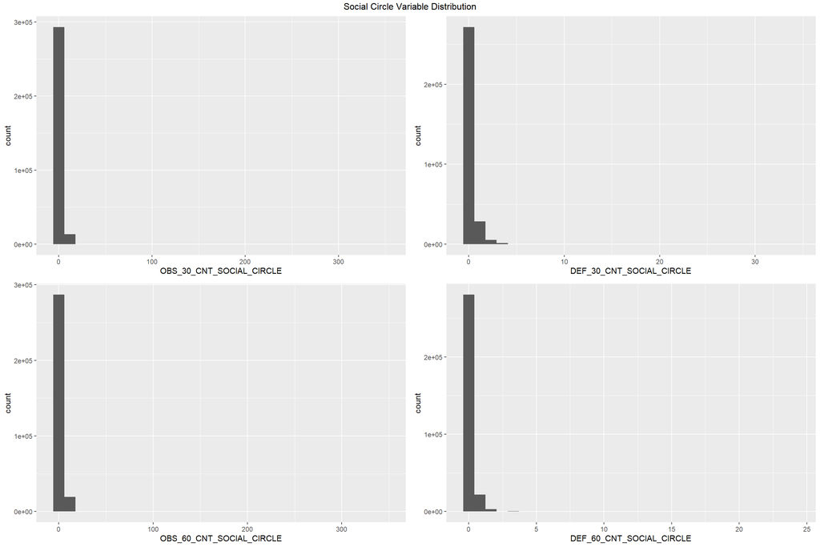

```r
plot_OBS_30 <- ggplot(social_data_df, aes(OBS_30_CNT_SOCIAL_CIRCLE)) +
  geom_histogram()
plot_DEF_30 <- ggplot(social_data_df, aes(DEF_30_CNT_SOCIAL_CIRCLE)) +
  geom_histogram()
plot_OBS_60 <- ggplot(social_data_df, aes(OBS_60_CNT_SOCIAL_CIRCLE)) +
  geom_histogram()
plot_DEF_60 <- ggplot(social_data_df, aes(DEF_60_CNT_SOCIAL_CIRCLE)) +
  geom_histogram()

grid.arrange(plot_OBS_30,plot_DEF_30,plot_OBS_60,plot_DEF_60, ncol=2, top=textGrob('Social Circle Variable Distribution'))
```

Given that there are relatively few rows with missing data and the data is heavily right-skewed, it is proposed that missing data in these columns be replaced with imputed zero values (*median*= 0),

## 11.4 External Source Data

Included in the dataset are 3 externally sourced scores which have been normalized. There is wide variation in the number of values missing in each of these sources ($NA_1=173378$,$NA_2=660$,$NA_3=60965$).

```r
summary(data %>% select(EXT_SOURCE_1,EXT_SOURCE_2,EXT_SOURCE_3))
```

```
##   EXT_SOURCE_1     EXT_SOURCE_2     EXT_SOURCE_3
##  Min.   :0.01     Min.   :0.0000   Min.   :0.00
##  1st Qu.:0.33     1st Qu.:0.3925   1st Qu.:0.37
##  Median :0.51     Median :0.5660   Median :0.54
##  Mean   :0.50     Mean   :0.5144   Mean   :0.51
##  3rd Qu.:0.68     3rd Qu.:0.6636   3rd Qu.:0.67
##  Max.   :0.96     Max.   :0.8550   Max.   :0.90
##  NA's   :173378   NA's   :660      NA's   :60965
```

```r
# Select rows with no External Source Data
n_empty_ext <- nrow(data %>% filter(is.na(EXT_SOURCE_1) & is.na(EXT_SOURCE_2) & is.na(EXT_SOURCE_3)))
```

Removing rows with missing data would shrink the dataset considerably. Imputation with the mean value for each column is a possibility. Another option is to create a new variable combining the scores into an AVG_EXT_SCORE since they are all normalized values. The benefit to this approach is that only 172 rows have no value for any of the 3 columns and so very little data would need to be imputed or removed. This approach takes advantage of available information, while reducing missing data. However it is possible that some information loss will occur with this approach if one of these sources turns out to be much more informative than one or both of the others.

## 11.5 Credit Bureau Data

The final large group of related data deals with credit inquiries from the credit bureau over the previous year. These are divided into the hour, day, week, month, quarter, and year (each time period is exclusive of the time period before it) prior to the application being submitted. This data is strongly right-skewed and is 86.5% complete (NAs = 41519).

```r
summary(data %>% select(AMT_REQ_CREDIT_BUREAU_HOUR,AMT_REQ_CREDIT_BUREAU_DAY,AMT_REQ_CREDIT_BUREAU_WEEK,AMT_REQ_CREDIT_BUREAU_MON,
                        AMT_REQ_CREDIT_BUREAU_QRT,AMT_REQ_CREDIT_BUREAU_YEAR))
```

```
##  AMT_REQ_CREDIT_BUREAU_HOUR AMT_REQ_CREDIT_BUREAU_DAY AMT_REQ_CREDIT_BUREAU_WEEK AMT_REQ_CREDIT_BUREAU_MON AMT_REQ_CREDIT_BUREAU_QRT AMT_REQ_CREDIT_BUREAU_YEAR
##  Min.   :0.00               Min.   :0.00              Min.   :0.00               Min.   : 0.00             Min.   :  0.00            Min.   : 0.0
##  1st Qu.:0.00               1st Qu.:0.00              1st Qu.:0.00               1st Qu.: 0.00             1st Qu.:  0.00            1st Qu.: 0.0
##  Median :0.00               Median :0.00              Median :0.00               Median : 0.00             Median :  0.00            Median : 1.0
##  Mean   :0.01               Mean   :0.01              Mean   :0.03               Mean   : 0.27             Mean   :  0.27            Mean   : 1.9
##  3rd Qu.:0.00               3rd Qu.:0.00              3rd Qu.:0.00               3rd Qu.: 0.00             3rd Qu.:  0.00            3rd Qu.: 3.0
##  Max.   :4.00               Max.   :9.00              Max.   :8.00               Max.   :27.00             Max.   :261.00            Max.   :25.0
##  NA's   :41519              NA's   :41519             NA's   :41519              NA's   :41519             NA's   :41519             NA's   :41519
```

While we could remove the 41519 rows missing data, the loss of other information in those records might be valuable, and so it is proposed to impute the missing values with the median value for each column, in most cases this is 0.

## 11.6 Other Data

There are a few remaining columns that contain missing data OWN_CAR_AGE, AMT_GOODS_PRICE, AMT_ANNUITY, CNT_FAM_MEMBERS,and DAYS_LAST_PHONE_CHANGE. Of these columns only OWN_CAR_AGE has a significant number of missing values. There is another column which is related to car ownership, FLAG_OWN_CAR, which is a boolean field. Upon closer inspection it is evident that all of those records where FLAG_OWN_CAR = ‘N’ contain NAs, conversely only 5 records with a FLAG_OWN_CAR = ‘Y’ contain missing values.

```r
CrossTable(data$FLAG_OWN_CAR, is.na(data$OWN_CAR_AGE), prop.r = F, prop.c = F, prop.chisq = F, dnn = c('Owns Car','Contains Missing Values'))
```

```
##
##
##    Cell Contents
## |-------------------------|
## |                       N |
## |         N / Table Total |
## |-------------------------|
##
##
## Total Observations in Table:  307511
##
##
##              | Contains Missing Values
##     Owns Car |     FALSE |      TRUE | Row Total |
## -------------|-----------|-----------|-----------|
##            N |         0 |    202924 |    202924 |
##              |     0.000 |     0.660 |           |
## -------------|-----------|-----------|-----------|
##            Y |    104582 |         5 |    104587 |
##              |     0.340 |     0.000 |           |
## -------------|-----------|-----------|-----------|
## Column Total |    104582 |    202929 |    307511 |
## -------------|-----------|-----------|-----------|
##
##
```

Therefore, it is proposed to remove these 5 records, and to convert the OWN_CAR_AGE into a factor variable with levels: No Car Owned, 0-3 years, 4-6 years, etc.

The other columns contain so few observations that it is proposed that those rows with missing values be excluded.

# 12 Problems with the data

## 12.1 Outlier Detection

```r
skm_num <- skm %>% filter(skim_type == 'numeric') %>% filter(!skim_variable %in% housing_stats_cols) %>% select(skim_variable, numeric.p0, numeric.mean, numeric.p100, numeric.hist)
skm_num
```

```
## # A tibble: 63 × 5
##    skim_variable                 numeric.p0 numeric.mean numeric.p100 numeric.hist
##    <chr>                              <dbl>        <dbl>        <dbl> <chr>
##  1 SK_ID_CURR                  100002        278181.          4.56e+5 ▇▇▇▇▇
##  2 TARGET                           0             0.0807      1   e+0 ▇▁▁▁▁
##  3 CNT_CHILDREN                     0             0.417       1.9 e+1 ▇▁▁▁▁
##  4 AMT_INCOME_TOTAL             25650        168798.          1.17e+8 ▇▁▁▁▁
##  5 AMT_CREDIT                   45000        599026.          4.05e+6 ▇▂▁▁▁
##  6 AMT_ANNUITY                   1616.        27109.          2.58e+5 ▇▁▁▁▁
##  7 AMT_GOODS_PRICE              40500        538396.          4.05e+6 ▇▂▁▁▁
##  8 REGION_POPULATION_RELATIVE       0.00029       0.0209      7.25e-2 ▇▇▃▁▁
##  9 DAYS_BIRTH                  -25229        -16037.         -7.49e+3 ▃▆▇▇▅
## 10 DAYS_EMPLOYED               -17912         63815.          3.65e+5 ▇▁▁▁▂
## 11 DAYS_REGISTRATION           -24672         -4986.          0       ▁▁▂▅▇
## 12 DAYS_ID_PUBLISH              -7197         -2994.          0       ▁▆▇▆▅
## 13 OWN_CAR_AGE                      0            12.1         9.1 e+1 ▇▁▁▁▁
## 14 FLAG_MOBIL                       0             1.00        1   e+0 ▁▁▁▁▇
## 15 FLAG_EMP_PHONE                   0             0.820       1   e+0 ▂▁▁▁▇
## 16 FLAG_WORK_PHONE                  0             0.199       1   e+0 ▇▁▁▁▂
## 17 FLAG_CONT_MOBILE                 0             0.998       1   e+0 ▁▁▁▁▇
## 18 FLAG_PHONE                       0             0.281       1   e+0 ▇▁▁▁▃
## 19 FLAG_EMAIL                       0             0.0567      1   e+0 ▇▁▁▁▁
## 20 CNT_FAM_MEMBERS                  1             2.15        2   e+1 ▇▁▁▁▁
## 21 REGION_RATING_CLIENT             1             2.05        3   e+0 ▁▁▇▁▂
## 22 REGION_RATING_CLIENT_W_CITY      1             2.03        3   e+0 ▁▁▇▁▂
## 23 HOUR_APPR_PROCESS_START          0            12.1         2.3 e+1 ▁▃▇▆▁
## 24 REG_REGION_NOT_LIVE_REGION       0             0.0151      1   e+0 ▇▁▁▁▁
## # ℹ 39 more rows
```

Some modelling techniques are susceptible to outsized influence by outliers (regression for example). After examining the distribution of the numeric data a few columns stand out as containing likely outliers. The first examples are CNT_FAM_MEMBERS and CNT_CHILDREN.

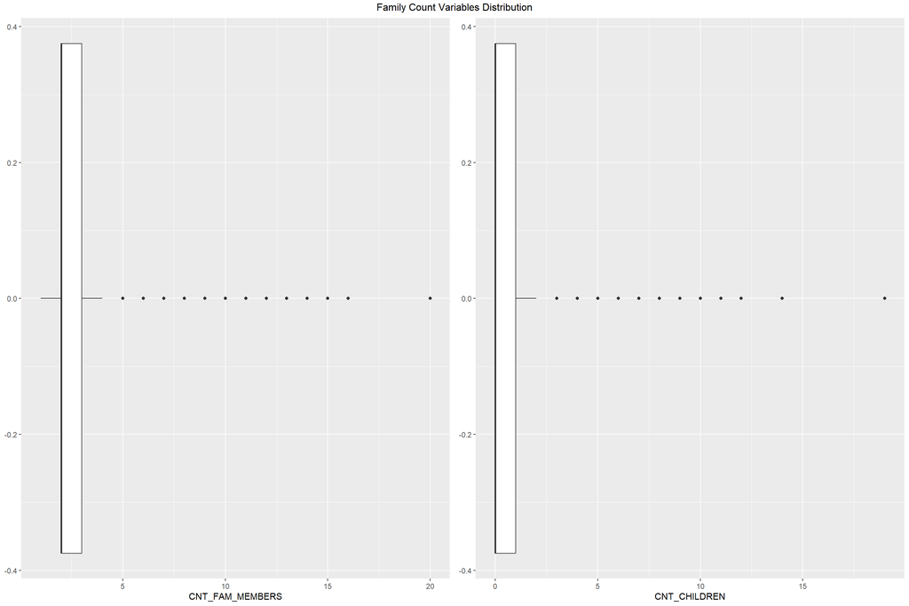

```r
# Create dataframe with columns of concern for plotting
num_problem_df <- data %>% select(CNT_CHILDREN, CNT_FAM_MEMBERS, AMT_INCOME_TOTAL, OWN_CAR_AGE, DAYS_LAST_PHONE_CHANGE, DAYS_EMPLOYED) %>% filter(!is.na(CNT_FAM_MEMBERS))

# Create Plots for family columns
plt_fam <- ggplot(num_problem_df, aes(CNT_FAM_MEMBERS)) +
  geom_boxplot()
plt_chld <- ggplot(num_problem_df, aes(CNT_CHILDREN)) +
  geom_boxplot()

grid.arrange(plt_fam, plt_chld, ncol=2, top=textGrob('Family Count Variables Distribution'))
```

Both of these columns (which are related) contain a small number of outlier records, however the information is consistent and is likely to have an influence on the target variable. As such, it is recommended that this variable is normalized before it is used in any modelling techniques that are suceptible to the presence of outliers.

## 12.2 Erroneous Data

In the case of AMT_INCOME_TOTAL there is a single outlier that lies so far out of the scale (AMT_INCOME_TOTAL = 117,000,000) and is inconsistent with other data, and so is probably erroneous. Even if not erroneous, the value added by this datapoint to any model is negligible as the core customer group is not multi-millionaires.

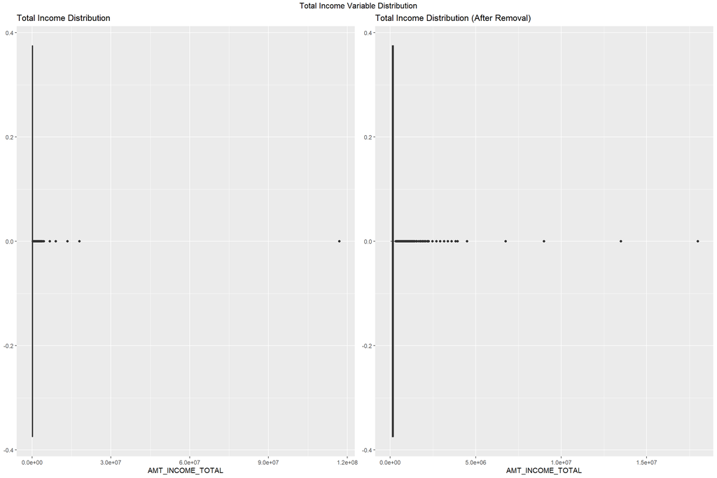

```r
plt_inc <- ggplot(num_problem_df, aes(AMT_INCOME_TOTAL)) +
  geom_boxplot() +
  ggtitle('Total Income Distribution')

# data %>% filter(AMT_INCOME_TOTAL > 100000000)
plt_inc2 <- ggplot(data %>% filter(AMT_INCOME_TOTAL < 100000000), aes(AMT_INCOME_TOTAL)) +
  geom_boxplot() +
  ggtitle('Total Income Distribution (After Removal)')

grid.arrange(plt_inc,plt_inc2, ncol=2, top=textGrob('Total Income Variable Distribution'))
```

Even after removal, outliers remain and measures (see above) will have to be taken to ensure they do not overly influence predictive models. In the case of such strongly skewed data, it might be advisable to convert the continuous variable into a categorical one and break the data into bins for use in models.

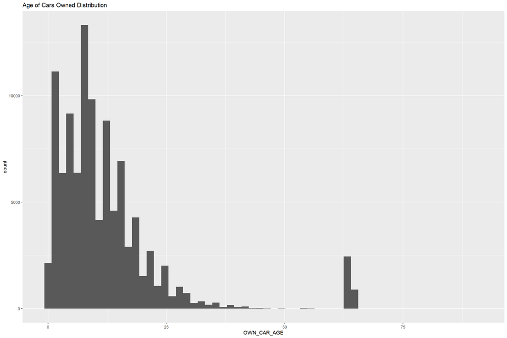

```r
ggplot(num_problem_df, aes(OWN_CAR_AGE)) +
  geom_histogram(bins = 60) +
  ggtitle('Age of Cars Owned Distribution')
```

```r
data %>% filter(OWN_CAR_AGE > 55) %>% select(SK_ID_CURR, OWN_CAR_AGE) %>% group_by('Cars older than 55 years' = as.factor(OWN_CAR_AGE))%>%count()
```

```
## # A tibble: 7 × 2
## # Groups:   Cars older than 55 years [7]
##   `Cars older than 55 years`     n
##   <fct>                      <int>
## 1 56                             1
## 2 57                             1
## 3 63                             2
## 4 64                          2443
## 5 65                           891
## 6 69                             1
## 7 91                             2
```

There is an odd anomaly in the data such that a large number of owned cars are recorded as being 64-65 years old. It seems unlikely that this data correctly represents reality. The amount of erroneous data is small and so removal wouldn’t impact the overall dataset to a large degree. However, the other data contained in these records may be informative, and so it is proposed that if the variable OWN_CAR_AGE is to be used in a model, that these rows be removed.

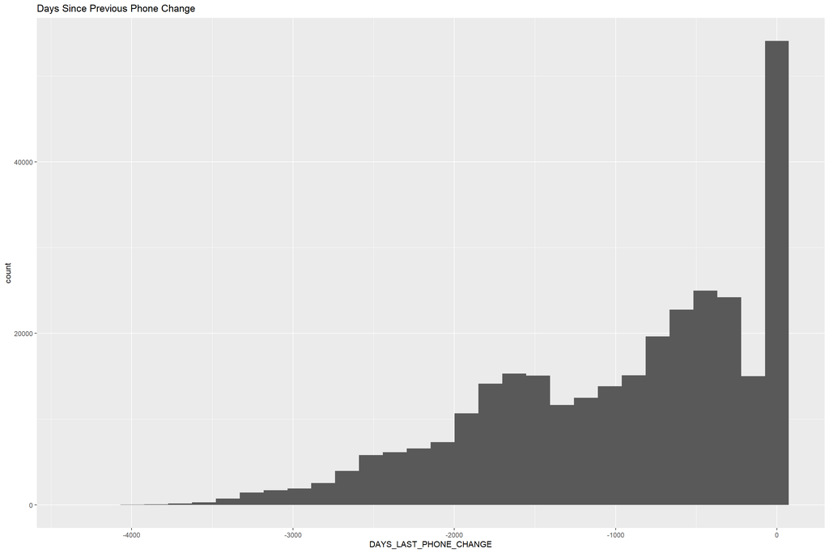

```r
ggplot(num_problem_df, aes(DAYS_LAST_PHONE_CHANGE)) +
  geom_histogram() +
  ggtitle('Days Since Previous Phone Change')
```

```r
data %>% filter(DAYS_EMPLOYED > 0) %>% select(SK_ID_CURR, DAYS_EMPLOYED) %>% group_by('Days Employed' = as.factor(DAYS_EMPLOYED))%>%count()
```

```
## # A tibble: 1 × 2
## # Groups:   Days Employed [1]
##   `Days Employed`     n
##   <fct>           <int>
## 1 365243          55374
```

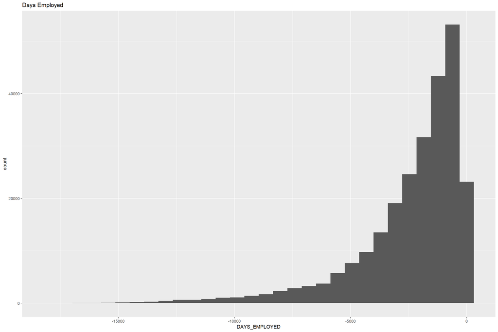

```r
ggplot(num_problem_df %>% filter(DAYS_EMPLOYED < 0), aes(DAYS_EMPLOYED)) +
  geom_histogram() +
  ggtitle('Days Employed')
```

```r
de_df <- data %>% filter(DAYS_EMPLOYED < 0)
```

Finally, DAYS_EMPLOYED has significant data integrity issues. The way the data is set up only values less than or equal to 0 should be permissible. However, a significant number of rows (n = 55374) all have the same positive value, DAYS_EMPLOYED = 365243. Not only should the value be negative, but the scale is also outside of realistic values (365243 days = 1000+ years). Due to these rows comprising a significant portion of the data set (18%) removal would be detrimental to model accuracy, so it is proposed that the data be imputed for these rows, being replaced by the column median (median = -1648)

```r
app_train <- read_csv("../data/application_train.csv") %>%
  rename_with(~tolower(.))
```

# 13 Basic inspection of application train data

## 13.1 Class proportions of target variable

```r
table(app_train$target)
```

```
##
##      0      1
## 282686  24825
```

```r
table(app_train$target) %>%
  prop.table() %>%
  round(3)
```

```
##
##     0     1
## 0.919 0.081
```

Only 8.1% of individuals in train set experience payment difficulties. In other words, the no-information rate is 92% which means model accuracy will need to exceed that in order to be meaningful/useful. Special attention should also be given to model Sensitivity and Specificity.

## 13.2 Scope of missing values

### 13.2.1 Rowwise completeness

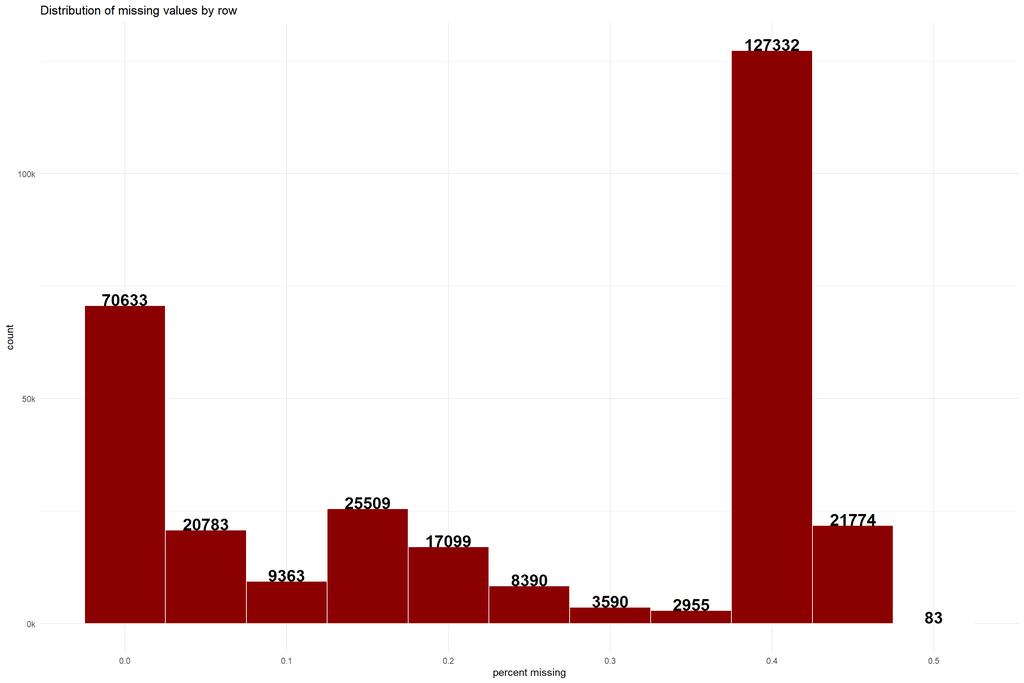

```r
app_train %>%
  mutate(n_missing = rowSums(is.na(.)),
         p_missing = n_missing/ncol(.)) %>%
  ggplot() +
  geom_histogram(aes(p_missing),
                 binwidth = 0.05, fill = "darkred", color = "white") +
  stat_bin(aes(p_missing, y = after_stat(count), label = ifelse(after_stat(count) == 0, "", after_stat(count))),
           geom = "text", binwidth = 0.05, size = 6, fontface = "bold", vjust = 0) +
  scale_x_continuous(breaks = seq(0,1,0.1), minor_breaks = NULL) +
  scale_y_continuous(labels = ~paste0(.%/%1000, "k")) +
  labs(title = "Distribution of missing values by row",
       x = "percent missing") +
  theme_minimal()
```

### 13.2.2 Columns with most NA’s

```r
app_train %>%
  summarise(across(everything(), ~sum(is.na(.)))) %>%
  pivot_longer(everything(),
               names_to = "col",
               values_to = "n_missing") %>%
  mutate(p_missing = percent(n_missing / nrow(app_train), 0.1)) %>%
  arrange(-n_missing) %>%
  head(20)
```

```
## # A tibble: 20 × 3
##    col                      n_missing p_missing
##    <chr>                        <int> <chr>
##  1 commonarea_avg              214865 69.9%
##  2 commonarea_mode             214865 69.9%
##  3 commonarea_medi             214865 69.9%
##  4 nonlivingapartments_avg     213514 69.4%
##  5 nonlivingapartments_mode    213514 69.4%
##  6 nonlivingapartments_medi    213514 69.4%
##  7 fondkapremont_mode          210295 68.4%
##  8 livingapartments_avg        210199 68.4%
##  9 livingapartments_mode       210199 68.4%
## 10 livingapartments_medi       210199 68.4%
## 11 floorsmin_avg               208642 67.8%
## 12 floorsmin_mode              208642 67.8%
## 13 floorsmin_medi              208642 67.8%
## 14 years_build_avg             204488 66.5%
## 15 years_build_mode            204488 66.5%
## 16 years_build_medi            204488 66.5%
## 17 own_car_age                 202929 66.0%
## 18 landarea_avg                182590 59.4%
## 19 landarea_mode               182590 59.4%
## 20 landarea_medi               182590 59.4%
```

## 13.3 Inspecting numerical variables

### 13.3.1 Class conversion

There are many categorical variables in this table which are encoded numerically. With 122 total columns, it’s rather arduous to distinguish true numerical variables but selecting columns that only contain numbers (and NA’s) is an obvious start.

```r
# Ensuring data types were properly attributed during import
app_train %>%
  summarise(across(everything(),
                   list(assigned = class,
                        observed = \(xx){
                          case_when(grepl("^(\\d|\\.|-)+$", xx) | is.na(xx) ~ "numeric",
                                    .default = "character")
                        },
                        vsample = ~as.character(.))) %>%
            first) %>%
  pivot_longer(everything(),
               names_to = c("column", ".value"),
               names_pattern = "(.*)_(.*)") %>%
  filter(assigned != observed) # subset mismatches
```

```
## # A tibble: 0 × 4
## # ℹ 4 variables: column <chr>, assigned <chr>, observed <chr>, vsample <chr>
```

Since no columns where misclassed during the importing process, we can move on to subsetting the numerical columns.

```r
app_train %>%
  select(where(is.numeric))
```

```
## # A tibble: 307,511 × 106
##    sk_id_curr target cnt_children amt_income_total amt_credit amt_annuity amt_goods_price region_population…¹ days_birth days_employed days_registration days_id_publish own_car_age flag_mobil flag_emp_phone flag_work_phone
##         <dbl>  <dbl>        <dbl>            <dbl>      <dbl>       <dbl>           <dbl>               <dbl>      <dbl>         <dbl>             <dbl>           <dbl>       <dbl>      <dbl>          <dbl>           <dbl>
##  1     100002      1            0          202500     406598.      24700.          351000             0.0188       -9461          -637             -3648           -2120          NA          1              1               0
##  2     100003      0            0          270000    1293502.      35698.         1129500             0.00354     -16765         -1188             -1186            -291          NA          1              1               0
##  3     100004      0            0           67500     135000        6750           135000             0.0100      -19046          -225             -4260           -2531          26          1              1               1
##  4     100006      0            0          135000     312682.      29686.          297000             0.00802     -19005         -3039             -9833           -2437          NA          1              1               0
##  5     100007      0            0          121500     513000       21866.          513000             0.0287      -19932         -3038             -4311           -3458          NA          1              1               0
##  6     100008      0            0           99000     490496.      27518.          454500             0.0358      -16941         -1588             -4970            -477          NA          1              1               1
##  7     100009      0            1          171000    1560726       41301          1395000             0.0358      -13778         -3130             -1213            -619          17          1              1               0
##  8     100010      0            0          360000    1530000       42075          1530000             0.00312     -18850          -449             -4597           -2379           8          1              1               1
##  9     100011      0            0          112500    1019610       33826.          913500             0.0186      -20099        365243             -7427           -3514          NA          1              0               0
## 10     100012      0            0          135000     405000       20250           405000             0.0197      -14469         -2019            -14437           -3992          NA          1              1               0
## 11     100014      0            1          112500     652500       21177           652500             0.0228      -10197          -679             -4427            -738          NA          1              1               0
## 12     100015      0            0           38419.    148365       10678.          135000             0.0152      -20417        365243             -5246           -2512          NA          1              0               0
```

[output cut: 19 more lines]

106/122 (87%) of columns in the train set are classified as numeric so this subsetting didn’t do much for us. It’s unlikely that categorical variables would be encoded with decimals/doubles or negative numbers, so we can remove these for now while we look through the rest of the variables’ description in the column description file.

```r
app_train %>%
  select(where(is.numeric)) %>%
  mutate(across(everything(), as.character)) %>%
  select(where(~ all(!grepl("\\.|-", .)))) %>%
  colnames() %>%
  tibble(column = .)
```

```
## # A tibble: 50 × 1
##    column
##    <chr>
##  1 sk_id_curr
##  2 target
##  3 cnt_children
##  4 own_car_age
##  5 flag_mobil
##  6 flag_emp_phone
##  7 flag_work_phone
##  8 flag_cont_mobile
##  9 flag_phone
## 10 flag_email
## 11 cnt_fam_members
## 12 region_rating_client
## 13 region_rating_client_w_city
## 14 hour_appr_process_start
## 15 reg_region_not_live_region
## 16 reg_region_not_work_region
## 17 live_region_not_work_region
## 18 reg_city_not_live_city
## 19 reg_city_not_work_city
## 20 live_city_not_work_city
## 21 obs_30_cnt_social_circle
## 22 def_30_cnt_social_circle
## 23 obs_60_cnt_social_circle
## 24 def_60_cnt_social_circle
## # ℹ 26 more rows
```

This brings us down to a much more manageable 50 columns. Further determination can be aided by the column description file. Once all categorical variables have been identified, they can be converted to factors. The new factors can easily be reconverted later if need be.

```r
num2fac <- app_train %>%
  select(where(is.numeric)) %>%
  mutate(across(everything(), as.character)) %>%
  select(where(~ all(!grepl("\\.|-", .)))) %>%
  select(-c(own_car_age, hour_appr_process_start, matches("^(obs|def|amt|cnt)"))) %>%
  colnames()

app_train1 <- app_train %>%
  mutate(across(c(where(is.character), all_of(num2fac)), factor))
```

### 13.3.2 Distribution and other characteristics

```r
app_train1 %>%
  select(where(is.numeric)) %>%
  summarise(across(everything(),
                   list(avg = ~mean(., na.rm = TRUE),
                        med = ~median(., na.rm = TRUE),
                        max = ~max(., na.rm = TRUE),
                        min = ~min(., na.rm = TRUE),
                        sd = ~sd(., na.rm = TRUE),
                        var = ~var(., na.rm = TRUE),
                        outupper = ~soutlier(.),
                        outlower = ~soutlier(., lower = TRUE))) %>%
              round(2)) %>%
  pivot_longer(everything(),
               names_to = c("column", ".value"),
               names_pattern = "(.*)_(.*)")
```

```
## # A tibble: 70 × 9
##    column                            avg       med          max       min        sd      var   outupper   outlower
##    <chr>                           <dbl>     <dbl>        <dbl>     <dbl>     <dbl>    <dbl>      <dbl>      <dbl>
##  1 cnt_children                     0.42      0           19         0         0.72 5.2 e- 1       2.5       -1.5
##  2 amt_income_total            168798.   147150    117000000     25650    237123.   5.62e+10  337500     -22500
##  3 amt_credit                  599026    513531      4050000     45000    402491.   1.62e+11 1616625    -537975
##  4 amt_annuity                  27109.    24903       258026.     1616.    14494.   2.10e+ 8   61704     -10584
##  5 amt_goods_price             538396.   450000      4050000     40500    369446.   1.36e+11 1341000    -423000
##  6 region_population_relative       0.02      0.02         0.07      0         0.01 0              0.06      -0.02
##  7 days_birth                  -16037    -15750        -7489    -25229      4364.   1.90e+ 7   -1510.    -30586.
##  8 days_employed                63815.    -1213       365243    -17912    141276.   2.00e+10    3418.     -6466.
##  9 days_registration            -4986.    -4504            0    -24672      3523.   1.24e+ 7    6194.    -15684.
## 10 days_id_publish              -2994.    -3254            0     -7197      1509.   2.28e+ 6    2148.     -8168.
## 11 own_car_age                     12.1       9           91         0        11.9  1.43e+ 2      30        -10
## 12 cnt_fam_members                  2.15      2           20         1         0.91 8.3 e- 1       4.5        0.5
## 13 hour_appr_process_start         12.1      12           23         0         3.27 1.07e+ 1      20          4
## 14 ext_source_1                     0.5       0.51         0.96      0.01      0.21 4   e- 2       1.19      -0.18
## 15 ext_source_2                     0.51      0.57         0.85      0         0.19 4   e- 2       1.07      -0.01
## 16 ext_source_3                     0.51      0.54         0.9       0         0.19 4   e- 2       1.12      -0.08
## 17 apartments_avg                   0.12      0.09         1         0         0.11 1   e- 2       0.28      -0.08
## 18 basementarea_avg                 0.09      0.08         1         0         0.08 1   e- 2       0.21      -0.06
## 19 years_beginexpluatation_avg      0.98      0.98         1         0         0.06 0              1          0.96
## 20 years_build_avg                  0.75      0.76         1         0         0.11 1   e- 2       1.03       0.48
## 21 commonarea_avg                   0.04      0.02         1         0         0.08 1   e- 2       0.12      -0.06
## 22 elevators_avg                    0.08      0            1         0         0.13 2   e- 2       0.3       -0.18
## 23 entrances_avg                    0.15      0.14         1         0         0.1  1   e- 2       0.41      -0.14
## 24 floorsmax_avg                    0.23      0.17         1         0         0.14 2   e- 2       0.58      -0.08
## # ℹ 46 more rows
```

# 14 Addressing problematic columns

Some missing values in `code_gender` and `organization_type` were encoded with the string `XNA` instead of being explicitly missing.

```r
unique(app_train1$code_gender)
```

```
## [1] M   F   XNA
## Levels: F M XNA
```

```r
unique(app_train1$organization_type)
```

```
##  [1] Business Entity Type 3 School                 Government             Religion               Other                  XNA                    Electricity            Medicine               Business Entity Type 2
## [10] Self-employed          Transport: type 2      Construction           Housing                Kindergarten           Trade: type 7          Industry: type 11      Military               Services
## [19] Security Ministries    Transport: type 4      Industry: type 1       Emergency              Security               Trade: type 2          University             Transport: type 3      Police
## [28] Business Entity Type 1 Postal                 Industry: type 4       Agriculture            Restaurant             Culture                Hotel                  Industry: type 7       Trade: type 3
## [37] Industry: type 3       Bank                   Industry: type 9       Insurance              Trade: type 6          Industry: type 2       Transport: type 1      Industry: type 12      Mobile
## [46] Trade: type 1          Industry: type 5       Industry: type 10      Legal Services         Advertising            Trade: type 5          Cleaning               Industry: type 13      Trade: type 4
## [55] Telecom                Industry: type 8       Realtor                Industry: type 6
## 58 Levels: Advertising Agriculture Bank Business Entity Type 1 Business Entity Type 2 Business Entity Type 3 Cleaning Construction Culture Electricity Emergency Government Hotel Housing ... XNA
```

This can be fixed with the following:

```r
app_train1 %>%
  select(code_gender, organization_type) %>%
  mutate(across(c(code_gender, organization_type),
                ~case_when(. != "XNA" ~ .))) %>% # Fix occurs here
  sapply(., unique) %>% # Displaying the results
  tibble(cols = names(.),
         val = .) %>%
  unnest(val) %>%
  arrange()
```

```
## # A tibble: 61 × 2
##    cols              val
##    <chr>             <fct>
##  1 code_gender       M
##  2 code_gender       F
##  3 code_gender       <NA>
##  4 organization_type Business Entity Type 3
##  5 organization_type School
##  6 organization_type Government
##  7 organization_type Religion
##  8 organization_type Other
##  9 organization_type <NA>
## 10 organization_type Electricity
## 11 organization_type Medicine
## 12 organization_type Business Entity Type 2
## 13 organization_type Self-employed
## 14 organization_type Transport: type 2
## 15 organization_type Construction
## 16 organization_type Housing
## 17 organization_type Kindergarten
## 18 organization_type Trade: type 7
## 19 organization_type Industry: type 11
## 20 organization_type Military
## 21 organization_type Services
## 22 organization_type Security Ministries
## 23 organization_type Transport: type 4
## 24 organization_type Industry: type 1
## # ℹ 37 more rows
```

`days_employed` contains some erroneous values. Most values of `days_employed` are negative and yield reasonable values when converted to positive years with $\left( x \div 365 \right) \times -1$ but those beginning > 0 equate to less than -1,000 years. What’s more is that all of the values greater than 0 equal 365243. It’s possible that this number may be used as a factor to calculate time or define a time interval. 365 (days) 24 (hours) 3 (?) is rather coincidental.

```r
# Maximum is extremely large and mean is greater than 3rd quartile
app_train1$days_employed %>%
  summary
```

```
##    Min. 1st Qu.  Median    Mean 3rd Qu.    Max.
##  -17912   -2760   -1213   63815    -289  365243
```

```r
# All values > 0 equal 365243
app_train1 %>%
  filter(days_employed > 0) %>%
  select(days_employed) %>%
  summary
```

```
##  days_employed
##  Min.   :365243
##  1st Qu.:365243
##  Median :365243
##  Mean   :365243
##  3rd Qu.:365243
##  Max.   :365243
```

```r
# days_employed converted to years
app_train1 %>%
  select(days_employed) %>%
  mutate(year_conv = round((days_employed / 365) * -1, 2)) %>%
  head(10)
```

```
## # A tibble: 10 × 2
##    days_employed year_conv
##            <dbl>     <dbl>
##  1          -637      1.75
##  2         -1188      3.25
##  3          -225      0.62
##  4         -3039      8.33
##  5         -3038      8.32
##  6         -1588      4.35
##  7         -3130      8.58
##  8          -449      1.23
##  9        365243  -1001.
## 10         -2019      5.53
```

This can be solved with the following:

```r
app_train1 %>%
  mutate(days_employed = case_when(days_employed <= 0 ~ days_employed))
```

```
## # A tibble: 307,511 × 122
##    sk_id_curr target name_contract_type code_gender flag_own_car flag_own_realty cnt_children amt_income_total amt_credit amt_annuity amt_goods_price name_type_suite name_income_type     name_education_…¹ name_family_sta…²
##    <fct>      <fct>  <fct>              <fct>       <fct>        <fct>                  <dbl>            <dbl>      <dbl>       <dbl>           <dbl> <fct>           <fct>                <fct>             <fct>
##  1 100002     1      Cash loans         M           N            Y                          0          202500     406598.      24700.          351000 Unaccompanied   Working              Secondary / seco… Single / not mar…
##  2 100003     0      Cash loans         F           N            N                          0          270000    1293502.      35698.         1129500 Family          State servant        Higher education  Married
##  3 100004     0      Revolving loans    M           Y            Y                          0           67500     135000        6750           135000 Unaccompanied   Working              Secondary / seco… Single / not mar…
##  4 100006     0      Cash loans         F           N            Y                          0          135000     312682.      29686.          297000 Unaccompanied   Working              Secondary / seco… Civil marriage
##  5 100007     0      Cash loans         M           N            Y                          0          121500     513000       21866.          513000 Unaccompanied   Working              Secondary / seco… Single / not mar…
##  6 100008     0      Cash loans         M           N            Y                          0           99000     490496.      27518.          454500 Spouse, partner State servant        Secondary / seco… Married
##  7 100009     0      Cash loans         F           Y            Y                          1          171000    1560726       41301          1395000 Unaccompanied   Commercial associate Higher education  Married
##  8 100010     0      Cash loans         M           Y            Y                          0          360000    1530000       42075          1530000 Unaccompanied   State servant        Higher education  Married
##  9 100011     0      Cash loans         F           N            Y                          0          112500    1019610       33826.          913500 Children        Pensioner            Secondary / seco… Married
## 10 100012     0      Revolving loans    M           N            Y                          0          135000     405000       20250           405000 Unaccompanied   Working              Secondary / seco… Single / not mar…
## 11 100014     0      Cash loans         F           N            Y                          1          112500     652500       21177           652500 Unaccompanied   Working              Higher education  Married
## 12 100015     0      Cash loans         F           N            Y                          0           38419.    148365       10678.          135000 Children        Pensioner            Secondary / seco… Married
```

[output cut: 19 more lines]

Time to repair all 3 variables, and update the data frame.

```r
app_train2 <- app_train1 %>%
  mutate(across(c(code_gender, organization_type),
                ~case_when(. != "XNA" ~ .)),
         days_employed = case_when(days_employed <= 0 ~ days_employed))
```